# Prolific Analysis

```r
library(here)
library(tidyverse)
library(ggtext)
library(DT)
library(yardstick)
library(caret)
library(tigerstats)
```

## Clean Data (or load cleaned data)

```r
# source(here("analysis", "prolific-data-cleaning.R"))
all_data_clean <- read_csv(here("data", "lineup_clean.csv")) |>
  mutate(across(lineup_id:version, ~ as.factor(.x)),
         direction = fct_relevel(direction, c("Positive", "Negative"))
         )
```

```r
# feedback |>
#   DT::datatable()
```

```r
# users |>
#   DT::datatable()
```

## EDA

Look at number of plots per participant

```r
# all_data_orig |>
#   count(participant_id) |>
#   DT::datatable(rownames = F)
```

```r
all_data_clean |>
  count(participant_id) |>
  DT::datatable(rownames = F)
```

| participant_id | n |
| --- | --- |
| 000b8e7bf06fd83392d2bfdb858e3706 | 12 |
| 00edfe80bc739babe25e088ed7ef1a3c | 12 |
| 01e6e0a07d59784c04c3a08fe3c220e3 | 12 |
| 02179d3a251e87e3a504d105e8818583 | 12 |
| 026f877210bdff8a225136492975ea6f | 12 |
| 03b59df1171aab66ddf4f4a7768263b8 | 12 |
| 0b634e84baa0acdee22673e0f55895e7 | 12 |
| 0c181af75273c327c0b4c4245cd12008 | 12 |
| 0c74c93f6a262c9bbb3871b0a2d9316d | 12 |
| 0cc5fab5a6077490de11b0ca5de4afc6 | 12 |

[output cut: 200 more lines]

Look at number of replications per treatment

```r
all_data_clean |>
  count(cpLoc, sigma, theta) |>
  complete(cpLoc, sigma, theta) |>
  arrange(-n) |>
  DT::datatable()
```

|  | cpLoc | sigma | theta | n |
| --- | --- | --- | --- | --- |
| 1 | 0.666666667 | 1 | 5 | 89 |
| 2 | 0.5 | 1 | -5 | 80 |
| 3 | 0.333333333 | 2 | -3 | 79 |
| 4 | 0.666666667 | 2 | -3 | 79 |
| 5 | 0.666666667 | 2 | -1 | 78 |
| 6 | 0.333333333 | 2 | -1 | 75 |
| 7 | 0.333333333 | 1 | 5 | 74 |
| 8 | 0.333333333 | 2 | -5 | 73 |
| 9 | 0.333333333 | 2 | 1 | 73 |
| 10 | 0.666666667 | 2 | 5 | 73 |

[output cut: 26 more lines]

Look at number of participants per version x treatment

```r
all_data_clean |>
  count(version, cpLoc, sigma, theta) |>
  complete(version, cpLoc, sigma, theta) |>
  arrange(-n) |>
  mutate(n = replace_na(n, 0)) |>
  DT::datatable()
```

|  | version | cpLoc | sigma | theta | n |
| --- | --- | --- | --- | --- | --- |
| 1 | A | 0.666666667 | 1 | 5 | 49 |
| 2 | A | 0.333333333 | 2 | -1 | 47 |
| 3 | A | 0.666666667 | 2 | 5 | 45 |
| 4 | A | 0.5 | 2 | -3 | 44 |
| 5 | A | 0.333333333 | 1 | 5 | 43 |
| 6 | A | 0.666666667 | 2 | -1 | 43 |
| 7 | A | 0.333333333 | 1 | -1 | 42 |
| 8 | A | 0.5 | 1 | -5 | 42 |
| 9 | B | 0.5 | 1 | 3 | 42 |
| 10 | A | 0.333333333 | 2 | -3 | 41 |

[output cut: 62 more lines]

Plot of all of that…

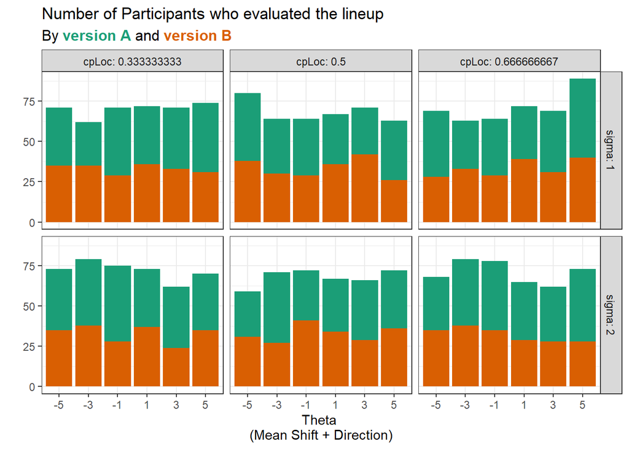

```r
all_data_clean |>
  count(version, cpLoc, sigma, theta) |>
  complete(version, cpLoc, sigma, theta) |>
  arrange(-n) |>
  mutate(n = replace_na(n, 0)) |>
  filter(theta != "0") |>
  ggplot(aes(x = theta,
             y = n,
             fill = version)
         ) +
  geom_bar(stat     = "identity",
           position = "stack") +
  facet_grid(sigma ~ cpLoc,
             labeller = label_both) +
  scale_fill_brewer(palette = "Dark2") +
  theme_bw() +
  labs(x = "Theta \n(Mean Shift + Direction)",
       y = "",
       title = "Number of Participants who evaluated the lineup",
       subtitle = str_c("By ", "<span style = 'color:#1B9E77'>**version A**</span>", " and ",
       "<span style = 'color:#D95F02'>**version B**</span>")
       ) +
  theme(plot.subtitle = ggtext::element_markdown(size = 12),
        legend.position = "none"
        )
```

Look at correctness

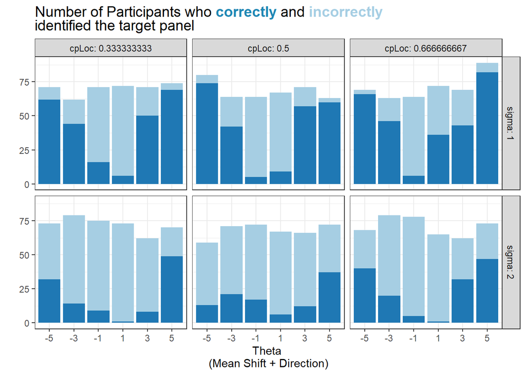

```r
all_data_clean |>
  select(participant_id, version, cpLoc, sigma, theta, correct, response_no, obs_plot_location) |>
  mutate(correct = factor(correct)) |>
  ggplot(aes(x = theta,
             fill = correct)
         ) +
  geom_bar(stat     = "count",
           position = "stack") +
  facet_grid(sigma ~ cpLoc,
             labeller = label_both) +
  scale_fill_brewer(palette = "Paired") +
  theme_bw() +
  labs(x = "Theta \n(Mean Shift + Direction)",
       y = "",
       title = str_c("Number of Participants who ", "<span style = 'color:#1F87B4'>**correctly**</span>", " and ",
       "<span style = 'color:#A6CEE3'>**incorrectly**</span>", "<br> identified the target panel")
       ) +
  theme(plot.title = ggtext::element_markdown(size = 14),
        legend.position = "none"
        )
```

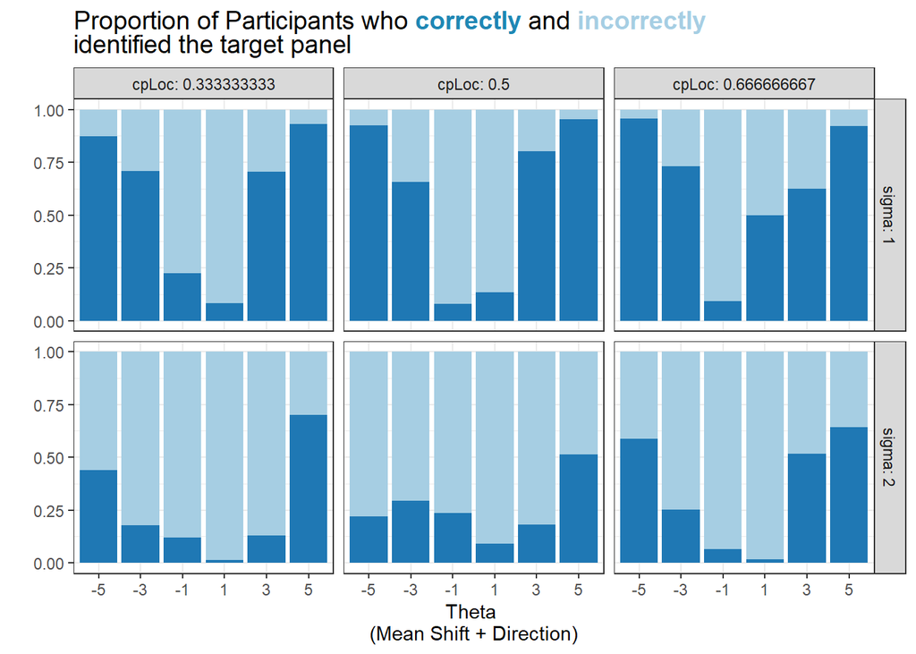

```r
all_data_clean |>
  select(participant_id, version, cpLoc, sigma, theta, correct, response_no, obs_plot_location) |>
  # complete(version, cpLoc, sigma, theta) |>
  mutate(correct = factor(correct)) |>
  ggplot(aes(x = theta,
             fill = correct)
         ) +
  geom_bar(stat     = "count",
           position = "fill") +
  facet_grid(sigma ~ cpLoc,
             labeller = label_both) +
  scale_fill_brewer(palette = "Paired") +
  theme_bw() +
  labs(x = "Theta \n(Mean Shift + Direction)",
       y = "",
       title = str_c("Proportion of Participants who ", "<span style = 'color:#1F87B4'>**correctly**</span>", " and ",
       "<span style = 'color:#A6CEE3'>**incorrectly**</span>", "<br> identified the target panel")
       ) +
  theme(plot.title = ggtext::element_markdown(size = 14),
        legend.position = "none"
        )
```

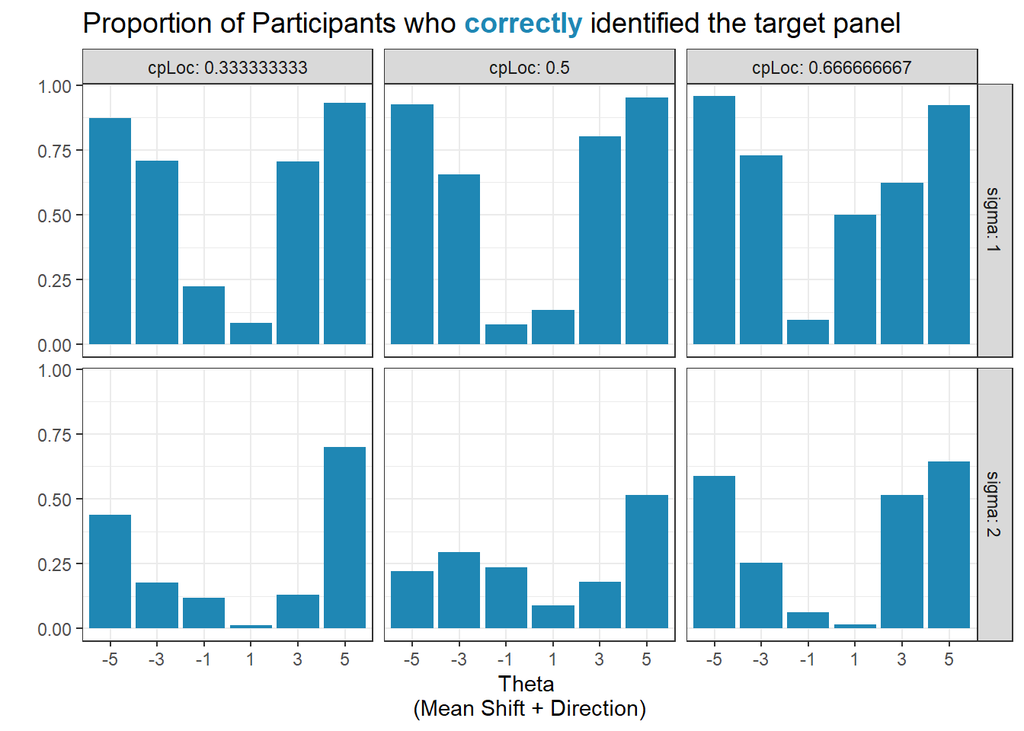

```r
all_data_clean |>
  select(participant_id, version, cpLoc, sigma, theta, correct, response_no, obs_plot_location) |>
  group_by(cpLoc, sigma, theta) |>
  summarize(prop_correct = sum(correct)/n()) |>
  ggplot(aes(x = theta,
             y = prop_correct)
         ) +
  geom_bar(stat = "identity",
           fill = "#1F87B4") +
  facet_grid(sigma ~ cpLoc,
             labeller = label_both) +
  theme_bw() +
  labs(x = "Theta \n(Mean Shift + Direction)",
       y = "",
       title = str_c("Proportion of Participants who ", "<span style = 'color:#1F87B4'>**correctly**</span>", " identified the target panel")
       ) +
  theme(plot.title = ggtext::element_markdown(size = 14)
        )
```

## Demographics

### Age

```r
all_data_clean |>
  count(age) |>
  mutate(n = n/12, #accounting for 12 responses from each person.
         percent=n/sum(n)*100)
```

```
# A tibble: 11 × 3
   age          n percent
   <chr>    <dbl>   <dbl>
 1 19-25      126  60
 2 26-30       50  23.8
 3 31-35        8   3.81
 4 36-40        8   3.81
 5 41-45        2   0.952
 6 46-50        5   2.38
 7 51-55        3   1.43
 8 56-60        1   0.476
 9 Over 60      2   0.952
10 Under 19     2   0.952
11 <NA>         3   1.43
```

### Gender

```r
all_data_clean |>
  count(gender) |>
  mutate(n = n/12, #accounting for 12 responses from each person.
         percent=n/sum(n)*100)
```

```
# A tibble: 5 × 3
  gender                    n percent
  <chr>                 <dbl>   <dbl>
1 Female                   77  36.7
2 Male                    127  60.5
3 Prefer not to answer      1   0.476
4 Variant/Nonconforming     2   0.952
5 <NA>                      3   1.43
```

### Educational Attainment

```r
all_data_clean |>
  count(academic_study) |>
  mutate(n = n/12, #accounting for 12 responses from each person.
         percent=n/sum(n)*100)
```

```
# A tibble: 7 × 3
  academic_study                 n percent
  <chr>                      <dbl>   <dbl>
1 Graduate Degree               66   31.4
2 High School or Less           29   13.8
3 Prefer not to answer           3    1.43
4 Some Graduate Courses         21   10
5 Some Undergraduate Courses    32   15.2
6 Undergraduate Degree          52   24.8
7 <NA>                           7    3.33
```

### Healthcare related jobs

```r
all_data_clean |>
  count(health_related) |>
  mutate(n = n/12, #accounting for 12 responses from each person.
         percent=n/sum(n)*100)
```

```
# A tibble: 4 × 3
  health_related           n percent
  <chr>                <dbl>   <dbl>
1 No                     180   85.7
2 Prefer not to answer     3    1.43
3 Yes                     24   11.4
4 <NA>                     3    1.43
```

### STEM related jobs

```r
all_data_clean |>
  count(stem_related) |>
  mutate(n = n/12, #accounting for 12 responses from each person.
         percent=n/sum(n)*100)
```

```
# A tibble: 4 × 3
  stem_related             n percent
  <chr>                <dbl>   <dbl>
1 No                     140  66.7
2 Prefer not to answer    10   4.76
3 Yes                     58  27.6
4 <NA>                     2   0.952
```

### Both Healthcare and STEM related jobs

```r
all_data_clean |>
  count(health_related,stem_related) |>
  mutate(n = n/12, #accounting for 12 responses from each person.
         percent=n/sum(n)*100)
```

```
# A tibble: 9 × 4
  health_related       stem_related             n percent
  <chr>                <chr>                <dbl>   <dbl>
1 No                   No                     125  59.5
2 No                   Prefer not to answer     5   2.38
3 No                   Yes                     50  23.8
4 Prefer not to answer Prefer not to answer     3   1.43
5 Yes                  No                      14   6.67
6 Yes                  Prefer not to answer     2   0.952
7 Yes                  Yes                      8   3.81
8 <NA>                 No                       1   0.476
9 <NA>                 <NA>                     2   0.952
```

## Binomial GLMM

[output not shown]

```r
library(lme4)
library(emmeans)

# mod_glm <- glm(correct ~ direction*theta*sigma*cpLoc + participant_id,
#              family = binomial(),
#              data = all_data_clean
#              )
# aov(mod_glm) |>
#   summary()

mod <- glmer(correct ~ direction*theta_abs*sigma*cpLoc + (1 | participant_id),
             family = binomial(),
             control = glmerControl(optimizer = "bobyqa",
                                    optCtrl   = list(maxfun = 20000)
             ),
             data = all_data_clean
             )
```

```r
# summary(mod)
car::Anova(mod)
```

```
Analysis of Deviance Table (Type II Wald chisquare tests)

Response: correct
                                   Chisq Df Pr(>Chisq)
direction                         6.6672  1   0.009821 **
theta_abs                       334.9603  2  < 2.2e-16 ***
sigma                           219.2497  1  < 2.2e-16 ***
cpLoc                            11.9805  2   0.002503 **
direction:theta_abs               7.8625  2   0.019619 *
direction:sigma                   0.1715  1   0.678748
theta_abs:sigma                  45.2223  2  1.514e-10 ***
direction:cpLoc                   3.2323  2   0.198667
theta_abs:cpLoc                   6.5034  4   0.164573
sigma:cpLoc                       4.0646  2   0.131033
direction:theta_abs:sigma        13.0077  2   0.001498 **
direction:theta_abs:cpLoc        30.4971  4  3.877e-06 ***
direction:sigma:cpLoc             6.8008  2   0.033360 *
theta_abs:sigma:cpLoc            32.8453  4  1.285e-06 ***
direction:theta_abs:sigma:cpLoc  13.8898  4   0.007655 **
---
Signif. codes:  0 '***' 0.001 '**' 0.01 '*' 0.05 '.' 0.1 ' ' 1
```

```r
anova(mod)
```

```
Analysis of Variance Table
                                npar  Sum Sq Mean Sq  F value
direction                          1  21.379  21.379  21.3791
theta_abs                          2 245.089 122.544 122.5445
sigma                              1 240.682 240.682 240.6819
cpLoc                              2   9.781   4.891   4.8907
direction:theta_abs                2   8.215   4.108   4.1077
direction:sigma                    1   1.023   1.023   1.0229
theta_abs:sigma                    2  38.070  19.035  19.0352
direction:cpLoc                    2   5.159   2.579   2.5793
theta_abs:cpLoc                    4   7.719   1.930   1.9296
sigma:cpLoc                        2   2.343   1.171   1.1715
direction:theta_abs:sigma          2  14.283   7.141   7.1415
direction:theta_abs:cpLoc          4  38.938   9.735   9.7345
direction:sigma:cpLoc              2   9.405   4.702   4.7023
theta_abs:sigma:cpLoc              4  31.628   7.907   7.9069
direction:theta_abs:sigma:cpLoc    4  13.299   3.325   3.3248
```

```r
# sum(mod)
```

# RESULTS 1: PROBABILITY OF DETECTION

```r
estimates <- emmeans(mod, ~ direction:theta_abs:sigma:cpLoc, type = "response", infer = c(T,T))

estimates |>
  as_tibble() |>
  mutate(cpLoc = case_when(cpLoc == "0.333333333" ~ 0.33,
                           cpLoc == "0.5" ~ 0.50,
                           cpLoc == "0.666666667" ~ 0.66)
         ) |>
  DT::datatable()
```

|  | direction | theta_abs | sigma | cpLoc | prob | SE | df | asymp.LCL | asymp.UCL | null | z.ratio | p.value |
| --- | --- | --- | --- | --- | --- | --- | --- | --- | --- | --- | --- | --- |
| 1 | Positive | 1 | 1 | 0.33 | 0.0723078232614744 | 0.0295592392385221 |  | 0.0318162031815662 | 0.156027315610002 | 0.5 | -5.79077986513189 | 7.00603522649908e-09 |
| 2 | Negative | 1 | 1 | 0.33 | 0.208088917152005 | 0.0501132494208665 |  | 0.126471532716672 | 0.32290710246429 | 0.5 | -4.39477307081345 | 1.10888531597127e-05 |
| 3 | Positive | 3 | 1 | 0.33 | 0.728101274524398 | 0.0555865747154328 |  | 0.606992023606283 | 0.82278558185532 | 0.5 | 3.50808335795841 | 0.000451347602261957 |
| 4 | Negative | 3 | 1 | 0.33 | 0.737876906788049 | 0.0587587857518996 |  | 0.608147378417772 | 0.836223627341026 | 0.5 | 3.40675680054921 | 0.0006573967522386 |
| 5 | Positive | 5 | 1 | 0.33 | 0.943648543377098 | 0.0255371273837526 |  | 0.867254222050691 | 0.977232602056561 | 0.5 | 5.8682258542581 | 4.40482968051697e-09 |
| 6 | Negative | 5 | 1 | 0.33 | 0.886019525903231 | 0.0378112351493231 |  | 0.788662530212316 | 0.941834731376803 | 0.5 | 5.47718645353269 | 4.3214180175886e-08 |
| 7 | Positive | 1 | 2 | 0.33 | 0.0109579102128187 | 0.0110017572014485 |  | 0.00151279283797211 | 0.0749472131293992 | 0.5 | -4.43558682782116 | 9.18218119181571e-06 |
| 8 | Negative | 1 | 2 | 0.33 | 0.104012296617452 | 0.0345602946025714 |  | 0.0531381782552704 | 0.193632492856073 | 0.5 | -5.80680911050862 | 6.36746613837329e-09 |
| 9 | Positive | 3 | 2 | 0.33 | 0.117110774008521 | 0.0407993282849851 |  | 0.0576781454646295 | 0.223273574293542 | 0.5 | -5.11939346672526 | 3.06519859278914e-07 |
| 10 | Negative | 3 | 2 | 0.33 | 0.159182326305954 | 0.0417141201410517 |  | 0.0931999763108723 | 0.258558421767132 | 0.5 | -5.34012743138283 | 9.28812707321675e-08 |

[output cut: 26 more lines]

### 4-way Probs – Change Point and Direction for each theta abs and sigma

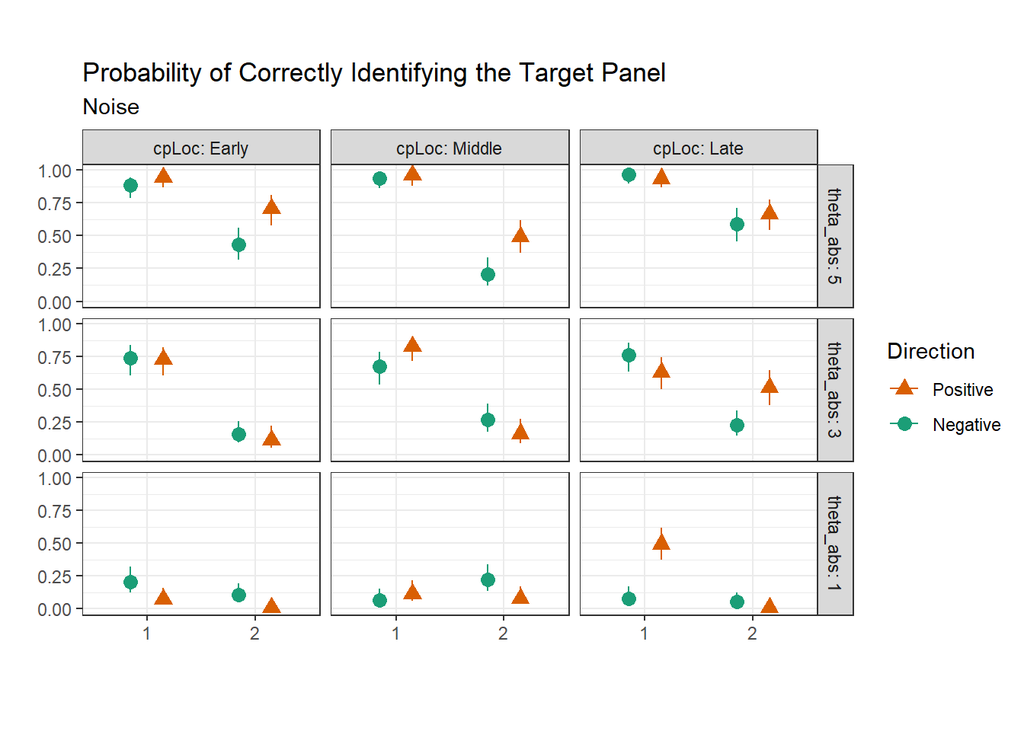

```r
emmeans(mod, ~ sigma:theta_abs:direction:cpLoc, type = "response", infer = c(T,T)) |>
  as_tibble() |>
  mutate(cpLoc = fct_recode(cpLoc,
                            "Early" = "0.333333333",
                            "Middle" = "0.5",
                            "Late" = "0.666666667"
                            ),
         theta_abs = fct_relevel(theta_abs,
                                 c("5", "3", "1")
                                 ),
         direction = fct_relevel(direction,
                                 c("Negative", "Positive")
                                 )
         ) |>
  ggplot(aes(x = sigma,
             color = direction,
             shape = direction
             )
         ) +
  geom_point(aes(y = prob),
             position = position_dodge(0.6),
             size=3
             ) +
  geom_errorbar(aes(ymin = asymp.LCL,
                    ymax = asymp.UCL
                    ),
                width = 0,
                position = position_dodge(0.6)
                ) +
  facet_grid(theta_abs ~ cpLoc,
             labeller = label_both
             ) +
  theme_bw() +
  theme(aspect.ratio = 0.6) +
  scale_color_brewer(palette = "Dark2") +
  labs(y = "",
       x = "",
       subtitle = "Noise",
       title = "Probability of Correctly Identifying the Target Panel",
       color = "Direction",
       shape = "Direction") +
  guides(shape = guide_legend(reverse = TRUE),
         color = guide_legend(reverse = TRUE))
```

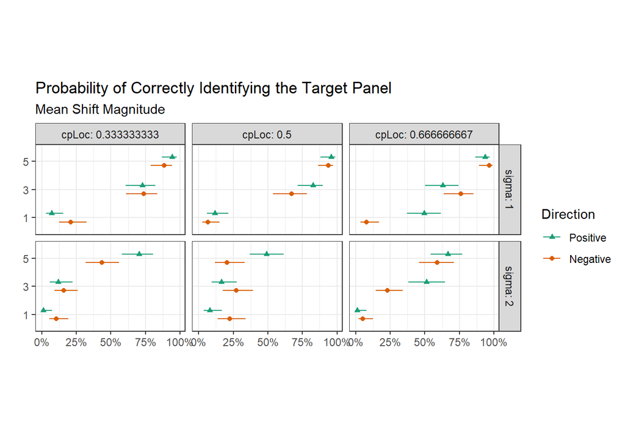

```r
emmeans(mod, ~ theta_abs:sigma:direction:cpLoc, type = "response") |>
  as_tibble() |>
  mutate(direction = fct_relevel(direction,
                                 c("Negative","Positive")
                                 )
         ) |>
  ggplot(aes(y = theta_abs,
             color = direction,
             shape = direction
             )
         ) +
  geom_point(aes(x = prob),
             position = position_dodge(0.6)
             ) +
  geom_errorbar(aes(xmin = asymp.LCL,
                    xmax = asymp.UCL
                    ),
                width = 0,
                position = position_dodge(0.6)
                ) +
  facet_grid(sigma ~ cpLoc, labeller = label_both) +
  theme_bw() +
  theme(aspect.ratio = 0.6) +
  scale_color_manual(values = c("#D95F02", "#1B9E77")) +
  labs(y = "",
       x = "",
       subtitle = "Mean Shift Magnitude",
       title = "Probability of Correctly Identifying the Target Panel",
       color = "Direction",
       shape = "Direction") +
  guides(shape = guide_legend(reverse = TRUE),
         color = guide_legend(reverse = TRUE)) +
  scale_x_continuous(labels = scales::percent)
```

# RESULT 2: COMPARE ODDS POSITIVE / ODDS NEGATIVE

### 4-way – Change Point and Direction for each theta abs and sigma

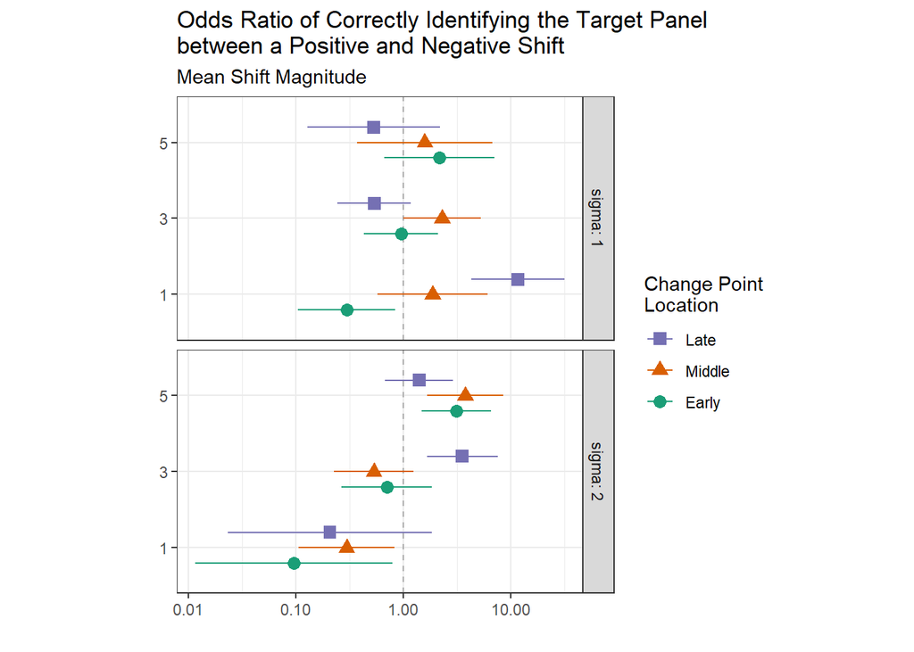

```r
emmeans(mod, ~ direction | theta_abs:cpLoc:sigma, type = "response") |>
  pairs(infer = c(T,T)) |>
  as_tibble() |>
  mutate(cpLoc = fct_recode(cpLoc,
                            "Early" = "0.333333333",
                            "Middle" = "0.5",
                            "Late" = "0.666666667")
         ) |>
  ggplot(aes(y = theta_abs,
             color = cpLoc,
             shape = cpLoc
             )
         ) +
  geom_vline(xintercept = 1,
             color = "darkgray",
             linetype = "dashed"
             ) +
  geom_point(aes(x = odds.ratio),
             position = position_dodge(0.6),
             size=3
             ) +
  geom_errorbar(aes(xmin = asymp.LCL,
                    xmax = asymp.UCL
                    ),
                width = 0,
                position = position_dodge(0.6)
                ) +
  facet_grid(sigma ~ .,
             labeller = label_both
             ) +
  theme_bw() +
  theme(aspect.ratio = 0.6) +
  scale_color_brewer(palette = "Dark2") +
  labs(y = "",
       x = "",
       subtitle = "Mean Shift Magnitude",
       title = "Odds Ratio of Correctly Identifying the Target Panel \nbetween a Positive and Negative Shift",
       color = "Change Point \nLocation",
       shape = "Change Point \nLocation") +
  guides(shape = guide_legend(reverse = TRUE),
         color = guide_legend(reverse = TRUE)) +
  scale_x_log10(labels = scales::comma)
```

Same as above, but switched plotting aesthetics

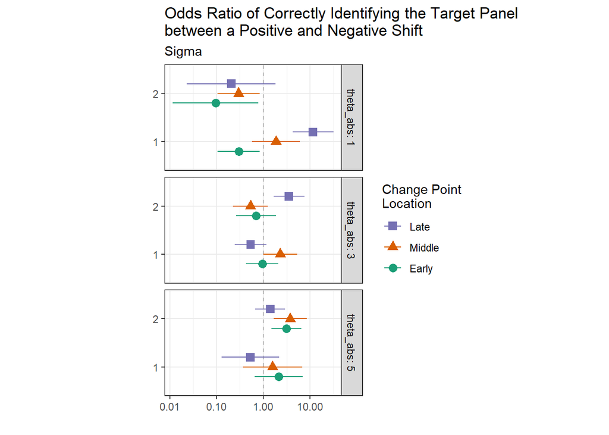

```r
emmeans(mod, ~ direction | theta_abs:cpLoc:sigma, type = "response") |>
  pairs(infer = c(T,T)) |>
  as_tibble() |>
  mutate(cpLoc = fct_recode(cpLoc,
                            "Early" = "0.333333333",
                            "Middle" = "0.5",
                            "Late" = "0.666666667")
         ) |>
  ggplot(aes(y = sigma,
             color = cpLoc,
             shape = cpLoc
             )
         ) +
  geom_vline(xintercept = 1,
             color = "darkgray",
             linetype = "dashed"
             ) +
  geom_point(aes(x = odds.ratio),
             position = position_dodge(0.6),
             size=3
             ) +
  geom_errorbar(aes(xmin = asymp.LCL,
                    xmax = asymp.UCL
                    ),
                width = 0,
                position = position_dodge(0.6)
                ) +
  facet_grid(theta_abs ~ .,
             labeller = label_both
             ) +
  theme_bw() +
  theme(aspect.ratio = 0.6) +
  scale_color_brewer(palette = "Dark2") +
  labs(y = "",
       x = "",
       subtitle = "Sigma",
       title = "Odds Ratio of Correctly Identifying the Target Panel \nbetween a Positive and Negative Shift",
       color = "Change Point \nLocation",
       shape = "Change Point \nLocation") +
  guides(shape = guide_legend(reverse = TRUE),
         color = guide_legend(reverse = TRUE)) +
  scale_x_log10(labels = scales::comma)
```

### 3-way – Change Point and Direction for each theta abs (averaged over sigma)

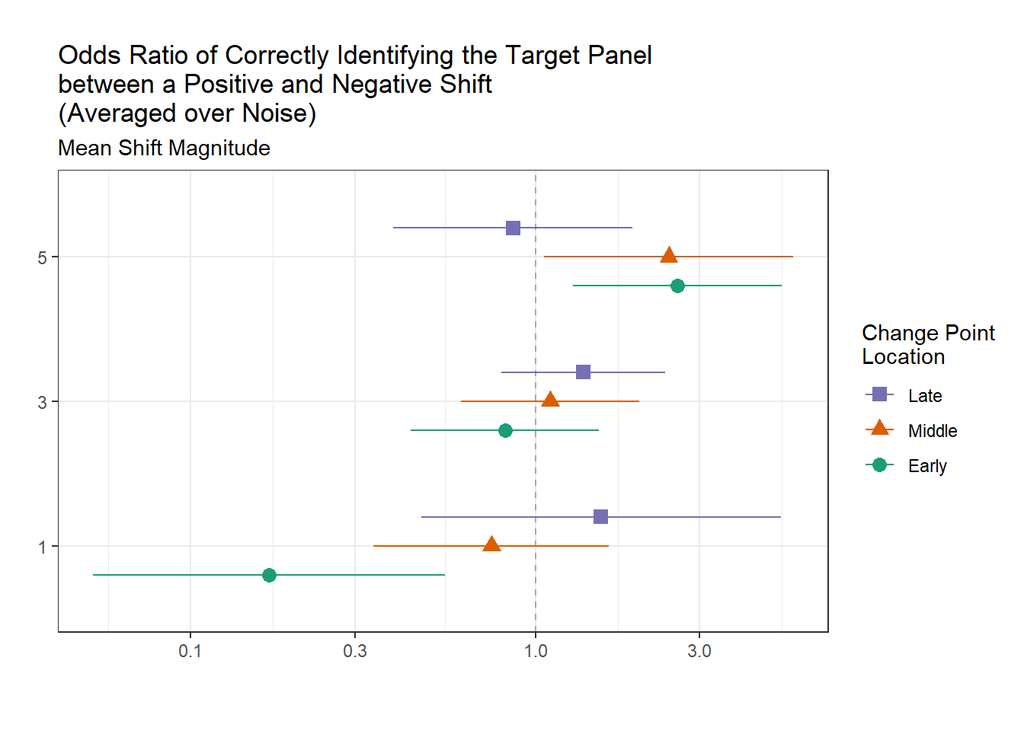

```r
emmeans(mod, ~ direction | theta_abs*cpLoc, type = "response") |>
  pairs(infer = c(T,T)) |>
  as_tibble() |>
  mutate(cpLoc = fct_recode(cpLoc,
                            "Early" = "0.333333333",
                            "Middle" = "0.5",
                            "Late" = "0.666666667")
         ) |>
  ggplot(aes(y = theta_abs,
             color = cpLoc,
             shape = cpLoc
             )
         ) +
  geom_vline(xintercept = 1,
             color = "darkgray",
             linetype = "dashed"
             ) +
  geom_point(aes(x = odds.ratio),
             position = position_dodge(0.6),
             size=3
             ) +
  geom_errorbar(aes(xmin = asymp.LCL,
                    xmax = asymp.UCL
                    ),
                width = 0,
                position = position_dodge(0.6)
                ) +
  # facet_grid(sigma ~ .,
  #            labeller = label_both
  #            ) +
  theme_bw() +
  theme(aspect.ratio = 0.6) +
  scale_color_brewer(palette = "Dark2") +
  labs(y = "",
       x = "",
       subtitle = "Mean Shift Magnitude",
       title = "Odds Ratio of Correctly Identifying the Target Panel \nbetween a Positive and Negative Shift \n(Averaged over Noise)",
       color = "Change Point \nLocation",
       shape = "Change Point \nLocation") +
  guides(shape = guide_legend(reverse = TRUE),
         color = guide_legend(reverse = TRUE)) +
  scale_x_log10(labels = scales::comma)
```

### 3-way – Change Point and Direction for each sigma (averaged over theta abs)

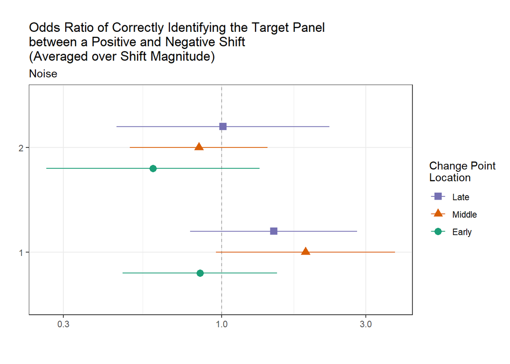

```r
emmeans(mod, ~ direction | sigma*cpLoc, type = "response") |>
  pairs(infer = c(T,T)) |>
  as_tibble() |>
  mutate(cpLoc = fct_recode(cpLoc,
                            "Early" = "0.333333333",
                            "Middle" = "0.5",
                            "Late" = "0.666666667")
         ) |>
  ggplot(aes(y = sigma,
             color = cpLoc,
             shape = cpLoc
             )
         ) +
  geom_vline(xintercept = 1,
             color = "darkgray",
             linetype = "dashed"
             ) +
  geom_point(aes(x = odds.ratio),
             position = position_dodge(0.6),
             size=3
             ) +
  geom_errorbar(aes(xmin = asymp.LCL,
                    xmax = asymp.UCL
                    ),
                width = 0,
                position = position_dodge(0.6)
                ) +
  # facet_grid(sigma ~ .,
  #            labeller = label_both
  #            ) +
  theme_bw() +
  theme(aspect.ratio = 0.6) +
  scale_color_brewer(palette = "Dark2") +
  labs(y = "",
       x = "",
       subtitle = "Noise",
       title = "Odds Ratio of Correctly Identifying the Target Panel \nbetween a Positive and Negative Shift \n(Averaged over Shift Magnitude)",
       color = "Change Point \nLocation",
       shape = "Change Point \nLocation") +
  guides(shape = guide_legend(reverse = TRUE),
         color = guide_legend(reverse = TRUE)) +
  scale_x_log10(labels = scales::comma)
```

### 2-way – Change Point and Direction (averaged over sigma and theta abs)

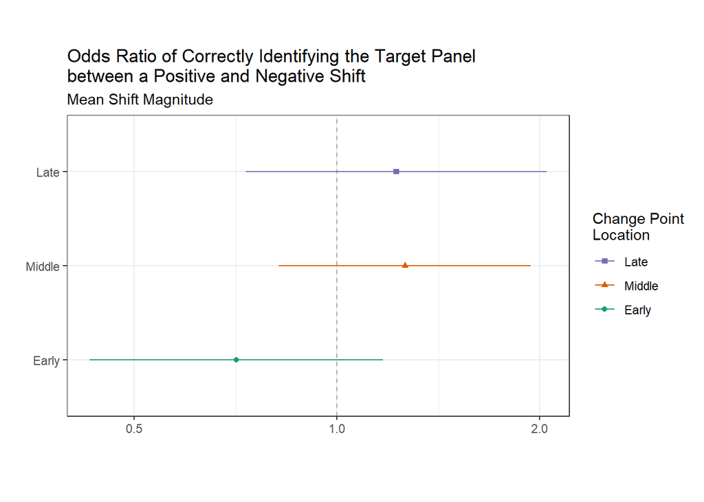

```r
emmeans(mod, ~ direction | cpLoc, type = "response") |>
  pairs(infer = c(T,T)) |>
  as_tibble() |>
  mutate(cpLoc = fct_recode(cpLoc,
                            "Early" = "0.333333333",
                            "Middle" = "0.5",
                            "Late" = "0.666666667")
         ) |>
  ggplot(aes(y = cpLoc,
             color = cpLoc,
             shape = cpLoc
             )
         ) +
  geom_vline(xintercept = 1,
             color = "darkgray",
             linetype = "dashed"
             ) +
  geom_point(aes(x = odds.ratio),
             position = position_dodge(0.6)
             ) +
  geom_errorbar(aes(xmin = asymp.LCL,
                    xmax = asymp.UCL
                    ),
                width = 0,
                position = position_dodge(0.6)
                ) +
  # facet_grid(sigma ~ .,
  #            labeller = label_both
  #            ) +
  theme_bw() +
  theme(aspect.ratio = 0.6) +
  scale_color_brewer(palette = "Dark2") +
  labs(y = "",
       x = "",
       subtitle = "Mean Shift Magnitude",
       title = "Odds Ratio of Correctly Identifying the Target Panel \nbetween a Positive and Negative Shift",
       color = "Change Point \nLocation",
       shape = "Change Point \nLocation") +
  guides(shape = guide_legend(reverse = TRUE),
         color = guide_legend(reverse = TRUE)) +
  scale_x_log10(labels = scales::comma)
```

# RESULTS 3: COMPARE ODDS LOW NOISE / ODDS HIGH NOISE

### 3-way Probs – Change Point and Direction for each theta abs and sigma

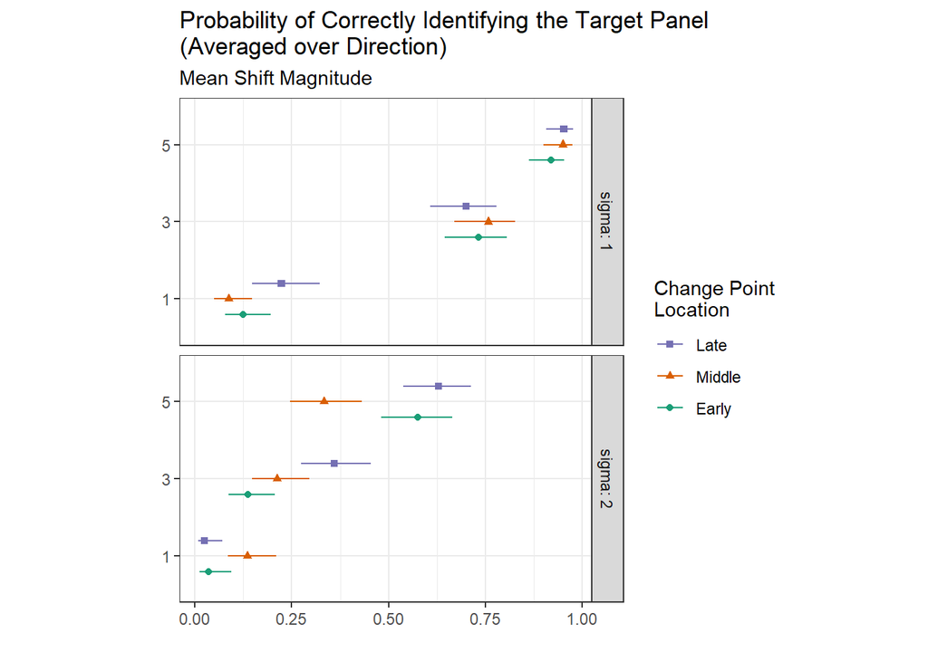

```r
emmeans(mod, ~ sigma:theta_abs:cpLoc, type = "response", infer = c(T,T)) |>
  as_tibble() |>
  mutate(cpLoc = fct_recode(cpLoc,
                            "Early" = "0.333333333",
                            "Middle" = "0.5",
                            "Late" = "0.666666667")
         ) |>
  ggplot(aes(y = theta_abs,
             color = cpLoc,
             shape = cpLoc
             )
         ) +
  geom_point(aes(x = prob),
             position = position_dodge(0.6)
             ) +
  geom_errorbar(aes(xmin = asymp.LCL,
                    xmax = asymp.UCL
                    ),
                width = 0,
                position = position_dodge(0.6)
                ) +
  facet_grid(sigma ~ .,
             labeller = label_both
             ) +
  theme_bw() +
  theme(aspect.ratio = 0.6) +
  scale_color_brewer(palette = "Dark2") +
  labs(y = "",
       x = "",
       subtitle = "Mean Shift Magnitude",
       title = "Probability of Correctly Identifying the Target Panel \n(Averaged over Direction)",
       color = "Change Point \nLocation",
       shape = "Change Point \nLocation") +
  guides(shape = guide_legend(reverse = TRUE),
         color = guide_legend(reverse = TRUE))
```

### 3-way Odds – Change Point and Direction for each theta abs and sigma (averaged over direction)

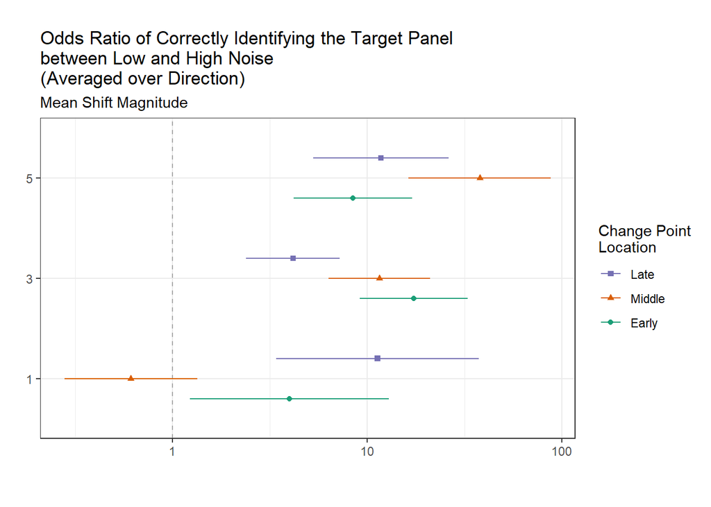

```r
emmeans(mod, ~ sigma | theta_abs:cpLoc, type = "response") |>
  pairs(infer = c(T,T)) |>
  as_tibble() |>
  mutate(cpLoc = fct_recode(cpLoc,
                            "Early" = "0.333333333",
                            "Middle" = "0.5",
                            "Late" = "0.666666667")
         ) |>
  ggplot(aes(y = theta_abs,
             color = cpLoc,
             shape = cpLoc
             )
         ) +
  geom_vline(xintercept = 1,
             color = "darkgray",
             linetype = "dashed"
             ) +
  geom_point(aes(x = odds.ratio),
             position = position_dodge(0.6)
             ) +
  geom_errorbar(aes(xmin = asymp.LCL,
                    xmax = asymp.UCL
                    ),
                width = 0,
                position = position_dodge(0.6)
                ) +
  # facet_grid(theta_abs ~ .,
  #            labeller = label_both
  #            ) +
  theme_bw() +
  theme(aspect.ratio = 0.6) +
  scale_color_brewer(palette = "Dark2") +
  labs(y = "",
       x = "",
       subtitle = "Mean Shift Magnitude",
       title = "Odds Ratio of Correctly Identifying the Target Panel \nbetween Low and High Noise \n(Averaged over Direction)",
       color = "Change Point \nLocation",
       shape = "Change Point \nLocation") +
  guides(shape = guide_legend(reverse = TRUE),
         color = guide_legend(reverse = TRUE)) +
  scale_x_log10(labels = scales::comma)
```

# RESULT 4: MAGNITUDE AND DIRECTION (FOR EACH NOISE LEVEL)

### Probability of Magnitude (high baseline) for Noise Level and Direction (averaged over cpLoc)

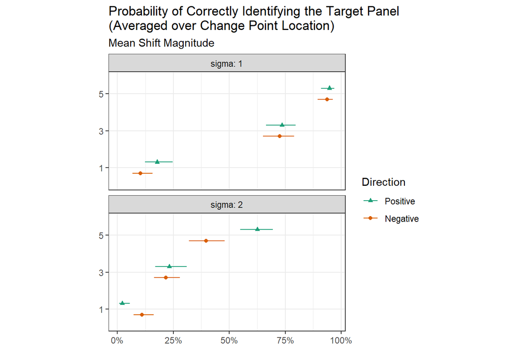

```r
emmeans(mod, ~ theta_abs | sigma:direction, type = "response") |>
  as_tibble() |>
  mutate(direction = fct_relevel(direction,
                                 c("Negative","Positive")
                                 )
         )|>
  ggplot(aes(y = theta_abs,
             color = direction,
             shape = direction
             )
         ) +
  geom_point(aes(x = prob),
             position = position_dodge(0.6)
             ) +
  geom_errorbar(aes(xmin = asymp.LCL,
                    xmax = asymp.UCL
                    ),
                width = 0,
                position = position_dodge(0.6)
                ) +
  facet_wrap(~ sigma, ncol = 1, labeller = label_both) +
  theme_bw() +
  theme(aspect.ratio = 0.5) +
  scale_color_manual(values = c("#D95F02", "#1B9E77")) +
  labs(y = "",
       x = "",
       subtitle = "Mean Shift Magnitude",
       title = "Probability of Correctly Identifying the Target Panel \n(Averaged over Change Point Location)",
       color = "Direction",
       shape = "Direction") +
  guides(shape = guide_legend(reverse = TRUE),
         color = guide_legend(reverse = TRUE)) +
  scale_x_continuous(labels = scales::percent)
```

```r
emmeans(mod, ~ sigma:theta_abs:direction, type = "response", infer = c(T,T)) |>
  as_tibble() |>
  ggplot(aes(y = sigma,
             color = direction,
             shape = direction
             )
         ) +
  geom_point(aes(x = prob),
             position = position_dodge(0.6)
             ) +
  geom_errorbar(aes(xmin = asymp.LCL,
                    xmax = asymp.UCL
                    ),
                width = 0,
                position = position_dodge(0.6)
                ) +
  facet_grid(theta_abs ~.,
             labeller = label_both
             ) +
  theme_bw() +
  theme(aspect.ratio = 0.6) +
  scale_color_brewer(palette = "Dark2") +
  labs(y = "",
       x = "",
       subtitle = "Noise",
       title = "Probability of Correctly Identifying the Target Panel \n(averaged over Change Point Location)",
       color = "Direction",
       shape = "Direction") +
  guides(shape = guide_legend(reverse = TRUE),
         color = guide_legend(reverse = TRUE))
```

[output not shown]

### Odds of Direction for Noise Level and Magnitude (averaged over cpLoc)

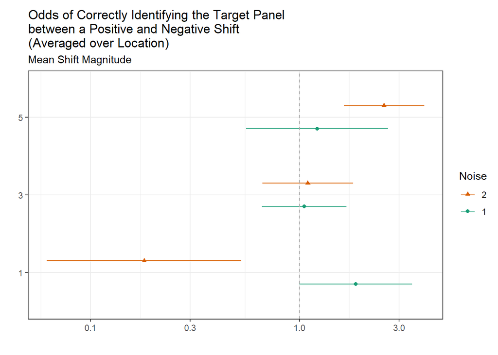

```r
emmeans(mod, ~ direction | sigma:theta_abs, type = "response") |>
  pairs(infer = c(T,T)) |>
  as_tibble() |>
  ggplot(aes(y = theta_abs,
             color = sigma,
             shape = sigma
             )
         ) +
  geom_point(aes(x = odds.ratio),
             position = position_dodge(0.6)
             ) +
  geom_errorbar(aes(xmin = asymp.LCL,
                    xmax = asymp.UCL
                    ),
                width = 0,
                position = position_dodge(0.6)
                ) +
  geom_vline(xintercept = 1,
             color = "darkgray",
             linetype = "dashed"
             ) +
  theme_bw() +
  theme(aspect.ratio = 0.6) +
  scale_color_brewer(palette = "Dark2") +
  labs(y = "",
       x = "",
       subtitle = "Mean Shift Magnitude",
       title = "Odds of Correctly Identifying the Target Panel \nbetween a Positive and Negative Shift \n(Averaged over Location)",
       color = "Noise",
       shape = "Noise") +
  guides(shape = guide_legend(reverse = TRUE),
         color = guide_legend(reverse = TRUE)) +
  scale_x_log10(labels = scales::comma)
```

### Odds of Magnitude (high baseline) for Noise Level and Direction (averaged over cpLoc)

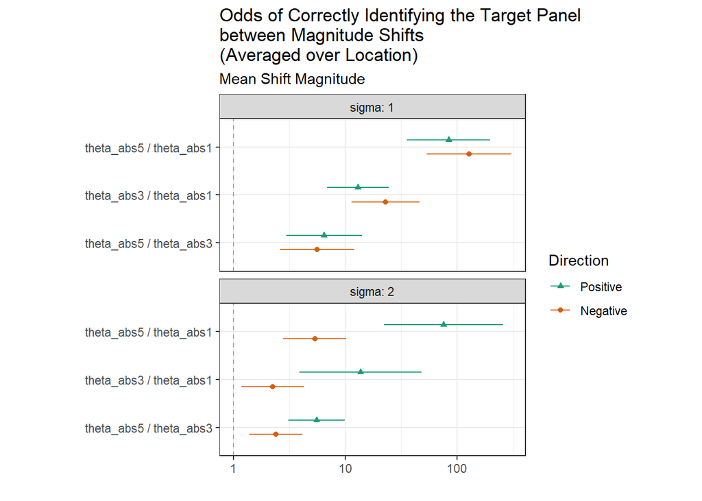

```r
emmeans(mod, ~ theta_abs | sigma:direction, type = "response", adjust = "dunnet") |>
  pairs(infer = c(T,T), reverse = TRUE) |>
  as_tibble() |>
  mutate(contrast = fct_relevel(contrast,
                                c("theta_abs5 / theta_abs3",
                                  "theta_abs3 / theta_abs1",
                                  "theta_abs5 / theta_abs1"
                                  )
                                )
        ) |>
  mutate(direction = fct_relevel(direction,
                                 c("Negative","Positive")
                                 )
         ) |>
  # filter(str_detect(contrast, pattern = "theta_abs5")) |>
  ggplot(aes(y = contrast,
             color = direction,
             shape = direction
             )
         ) +
  geom_point(aes(x = odds.ratio),
             position = position_dodge(0.6)
             ) +
  geom_errorbar(aes(xmin = asymp.LCL,
                    xmax = asymp.UCL
                    ),
                width = 0,
                position = position_dodge(0.6)
                ) +
  geom_vline(xintercept = 1,
             color = "darkgray",
             linetype = "dashed"
             ) +
  facet_wrap(~ sigma, ncol = 1, label = label_both) +
  theme_bw() +
  theme(aspect.ratio = 0.5) +
  scale_color_manual(values = c("#D95F02", "#1B9E77")) +
  labs(y = "",
       x = "",
       subtitle = "Mean Shift Magnitude",
       title = "Odds of Correctly Identifying the Target Panel \nbetween Magnitude Shifts \n(Averaged over Location)",
       color = "Direction",
       shape = "Direction") +
  guides(shape = guide_legend(reverse = TRUE),
         color = guide_legend(reverse = TRUE)) +
  scale_x_log10(labels = scales::comma)
```

### Odds of Magnitude (high baseline) for Noise Level and Direction for each over cpLoc

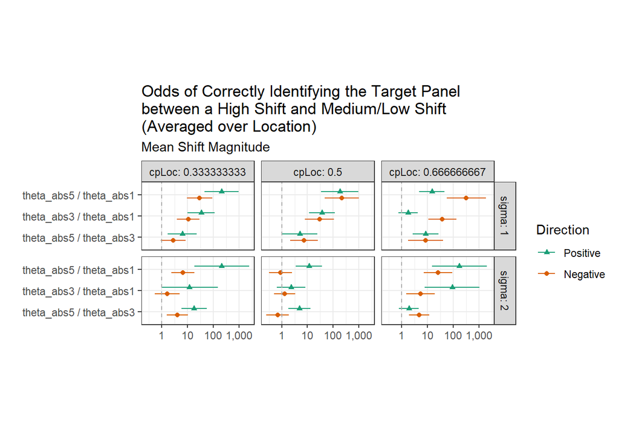

```r
emmeans(mod, ~ theta_abs | sigma:direction:cpLoc, type = "response", adjust = "dunnet") |>
  pairs(infer = c(T,T), reverse = TRUE) |>
  as_tibble() |>
  mutate(contrast = fct_relevel(contrast,
                                c("theta_abs5 / theta_abs3",
                                  "theta_abs3 / theta_abs1",
                                  "theta_abs5 / theta_abs1"
                                  )
                                )
        ) |>
  mutate(direction = fct_relevel(direction,
                                 c("Negative","Positive")
                                 )
         ) |>
  # filter(str_detect(contrast, pattern = "theta_abs5")) |>
  ggplot(aes(y = contrast,
             color = direction,
             shape = direction
             )
         ) +
  geom_point(aes(x = odds.ratio),
             position = position_dodge(0.6)
             ) +
  geom_errorbar(aes(xmin = asymp.LCL,
                    xmax = asymp.UCL
                    ),
                width = 0,
                position = position_dodge(0.6)
                ) +
  geom_vline(xintercept = 1,
             color = "darkgray",
             linetype = "dashed"
             ) +
  facet_grid(sigma ~ cpLoc, label = label_both) +
  theme_bw() +
  theme(aspect.ratio = 0.6) +
  scale_color_manual(values = c("#D95F02", "#1B9E77")) +
  labs(y = "",
       x = "",
       subtitle = "Mean Shift Magnitude",
       title = "Odds of Correctly Identifying the Target Panel \nbetween a High Shift and Medium/Low Shift \n(Averaged over Location)",
       color = "Direction",
       shape = "Direction") +
  guides(shape = guide_legend(reverse = TRUE),
         color = guide_legend(reverse = TRUE)) +
  scale_x_log10(labels = scales::comma)
```

### Odds of Magnitude (high baseline) for Noise Level (averaged over cpLoc and Direction)

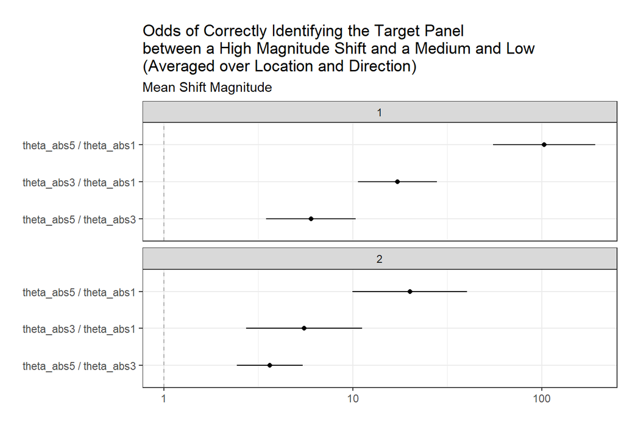

```r
emmeans(mod, ~ theta_abs | sigma, type = "response", adjust = "dunnet") |>
  pairs(infer = c(T,T), reverse = TRUE) |>
  as_tibble() |>
  mutate(contrast = fct_relevel(contrast,
                                c("theta_abs5 / theta_abs3",
                                  "theta_abs3 / theta_abs1",
                                  "theta_abs5 / theta_abs1"
                                  )
                                )
        ) |>
  # filter(str_detect(contrast, pattern = "theta_abs5")) |>
  ggplot(aes(y = contrast
             )
         ) +
  geom_point(aes(x = odds.ratio),
             position = position_dodge(0.6)
             ) +
  geom_errorbar(aes(xmin = asymp.LCL,
                    xmax = asymp.UCL
                    ),
                width = 0,
                position = position_dodge(0.6)
                ) +
  geom_vline(xintercept = 1,
             color = "darkgray",
             linetype = "dashed"
             ) +
  facet_wrap(~ sigma, ncol = 1) +
  theme_bw() +
  theme(aspect.ratio = 0.25) +
  # scale_color_brewer(palette = "Dark2") +
  labs(y = "",
       x = "",
       subtitle = "Mean Shift Magnitude",
       title = "Odds of Correctly Identifying the Target Panel \nbetween a High Magnitude Shift and a Medium and Low \n(Averaged over Location and Direction)") +
  scale_x_log10(labels = scales::comma)
```

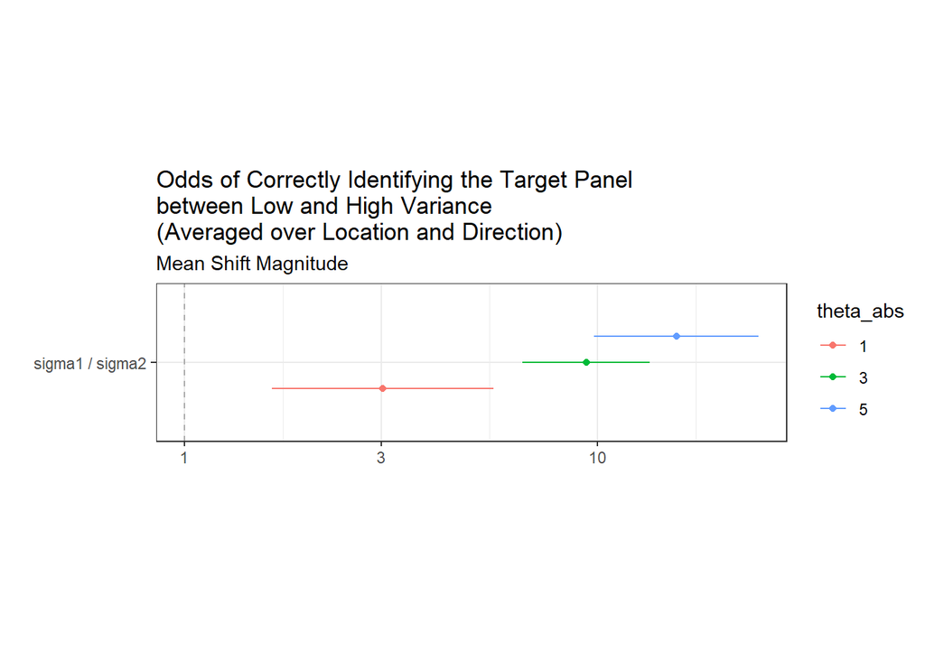

```r
emmeans(mod, ~ sigma|theta_abs, type = "response", adjust = "dunnet") |>
  pairs(infer = c(T,T))  |>
  as_tibble() |>

  # filter(str_detect(contrast, pattern = "theta_abs5")) |>
  ggplot(aes(y = contrast,group=theta_abs, color=theta_abs
             )
         ) +
  geom_point(aes(x = odds.ratio),
             position = position_dodge(0.6)
             ) +
  geom_errorbar(aes(xmin = asymp.LCL,
                    xmax = asymp.UCL
                    ),
                width = 0,
                position = position_dodge(0.6)
                ) +
  geom_vline(xintercept = 1,
             color = "darkgray",
             linetype = "dashed"
             ) +
  # facet_wrap(~ theta_abs, ncol = 1) +
  theme_bw() +
  theme(aspect.ratio = 0.25) +
  # scale_color_brewer(palette = "Dark2") +
  labs(y = "",
       x = "",
       subtitle = "Mean Shift Magnitude",
       title = "Odds of Correctly Identifying the Target Panel \nbetween Low and High Variance \n(Averaged over Location and Direction)") +
  scale_x_log10(labels = scales::comma)
```

#### Table of Odds ratio estimates (Shift Magnitude)

```r
emmeans(mod, ~ theta_abs | sigma, type = "response", adjust = "dunnet") |>
  pairs(infer = c(T,T), reverse = TRUE) |>
  as.data.frame() |>
  mutate(contrast = fct_relevel(contrast,
                                c("theta_abs5 / theta_abs3",
                                  "theta_abs3 / theta_abs1",
                                  "theta_abs5 / theta_abs1"
                                  )
                                )
        )
```

```
                 contrast sigma odds.ratio         SE  df asymp.LCL  asymp.UCL
1 theta_abs3 / theta_abs1     1  17.213182  3.5337088 Inf 10.639093  27.849521
2 theta_abs5 / theta_abs1     1 103.225815 27.4115983 Inf 55.398341 192.344546
3 theta_abs5 / theta_abs3     1   5.996905  1.4010384 Inf  3.468395  10.368735
4 theta_abs3 / theta_abs1     2   5.522725  1.6670488 Inf  2.722142  11.204589
5 theta_abs5 / theta_abs1     2  20.029088  5.9631616 Inf  9.968271  40.244125
6 theta_abs5 / theta_abs3     2   3.626668  0.6218587 Inf  2.426485   5.420482
  null   z.ratio      p.value
1    1 13.861678 0.000000e+00
2    1 17.461577 0.000000e+00
3    1  7.667110 7.083223e-14
4    1  5.661277 4.503902e-08
5    1 10.066958 3.352874e-14
6    1  7.513424 1.919576e-13
```

#### Table of Odds ratio estimates (Variance)

```r
emmeans(mod, ~ sigma|theta_abs, type = "response", adjust = "dunnet") |>
  pairs(infer = c(T,T))
```

```
theta_abs = 1:
 contrast        odds.ratio    SE  df asymp.LCL asymp.UCL null z.ratio p.value
 sigma1 / sigma2       3.02 0.953 Inf      1.63       5.6    1   3.499  0.0005

theta_abs = 3:
 contrast        odds.ratio    SE  df asymp.LCL asymp.UCL null z.ratio p.value
 sigma1 / sigma2       9.41 1.699 Inf      6.60      13.4    1  12.409  <.0001

theta_abs = 5:
 contrast        odds.ratio    SE  df asymp.LCL asymp.UCL null z.ratio p.value
 sigma1 / sigma2      15.55 3.636 Inf      9.84      24.6    1  11.740  <.0001

Results are averaged over the levels of: direction, cpLoc
Confidence level used: 0.95
Intervals are back-transformed from the log odds ratio scale
Tests are performed on the log odds ratio scale
```

# [MF] INTERACTION CONTRASTS

```r
emmeans(mod,~theta_abs:sigma:direction:cpLoc, type="response") |>
  emmeans::joint_tests(by=c("theta_abs","sigma"))
```

```
theta_abs = 1, sigma = 1:
 model term      df1 df2 F.ratio  Chisq p.value
 direction         1 Inf   3.839  3.839  0.0501
 cpLoc             2 Inf   4.181  8.362  0.0153
 direction:cpLoc   2 Inf  12.393 24.786  <.0001

theta_abs = 3, sigma = 1:
 model term      df1 df2 F.ratio  Chisq p.value
 direction         1 Inf   0.049  0.049  0.8247
 cpLoc             2 Inf   0.498  0.996  0.6078
 direction:cpLoc   2 Inf   3.134  6.268  0.0436

theta_abs = 5, sigma = 1:
 model term      df1 df2 F.ratio  Chisq p.value
 direction         1 Inf   0.240  0.240  0.6239
 cpLoc             2 Inf   0.908  1.816  0.4035
 direction:cpLoc   2 Inf   1.153  2.306  0.3156

theta_abs = 1, sigma = 2:
 model term      df1 df2 F.ratio  Chisq p.value
 direction         1 Inf   9.836  9.836  0.0017
 cpLoc             2 Inf   6.207 12.414  0.0020
 direction:cpLoc   2 Inf   0.453  0.906  0.6360

theta_abs = 3, sigma = 2:
 model term      df1 df2 F.ratio  Chisq p.value
 direction         1 Inf   0.130  0.130  0.7183
 cpLoc             2 Inf   8.520 17.040  0.0002
 direction:cpLoc   2 Inf   6.197 12.394  0.0020

theta_abs = 5, sigma = 2:
 model term      df1 df2 F.ratio  Chisq p.value
 direction         1 Inf  17.099 17.099  <.0001
 cpLoc             2 Inf  10.346 20.692  <.0001
 direction:cpLoc   2 Inf   1.855  3.710  0.1565
```

```r
emmeans(mod,~direction|cpLoc:theta_abs:sigma, type="response", adjust="tukey")|>
    pairs(infer = c(T,T)) |>
  as.data.frame()
```

```
cpLoc = 0.333333333, theta_abs = 1, sigma = 1:
 contrast            odds.ratio       SE  df asymp.LCL asymp.UCL null z.ratio
 Positive / Negative   0.296626 0.157082 Inf  0.105061  0.837480    1  -2.295
 p.value
  0.0217

cpLoc = 0.5, theta_abs = 1, sigma = 1:
 contrast            odds.ratio       SE  df asymp.LCL asymp.UCL null z.ratio
 Positive / Negative   1.873537 1.130959 Inf  0.573898  6.116310    1   1.040
 p.value
  0.2983

cpLoc = 0.666666667, theta_abs = 1, sigma = 1:
 contrast            odds.ratio       SE  df asymp.LCL asymp.UCL null z.ratio
 Positive / Negative  11.581096 5.901668 Inf  4.265615 31.442546    1   4.807
 p.value
  <.0001

cpLoc = 0.333333333, theta_abs = 3, sigma = 1:
 contrast            odds.ratio       SE  df asymp.LCL asymp.UCL null z.ratio
 Positive / Negative   0.951275 0.386885 Inf  0.428668  2.111013    1  -0.123
 p.value
  0.9022

cpLoc = 0.5, theta_abs = 3, sigma = 1:
 contrast            odds.ratio       SE  df asymp.LCL asymp.UCL null z.ratio
 Positive / Negative   2.300688 0.975147 Inf  1.002480  5.280071    1   1.966
 p.value
  0.0493

cpLoc = 0.666666667, theta_abs = 3, sigma = 1:
 contrast            odds.ratio       SE  df asymp.LCL asymp.UCL null z.ratio
 Positive / Negative   0.535139 0.215597 Inf  0.242960  1.178688    1  -1.552
 p.value
  0.1207

cpLoc = 0.333333333, theta_abs = 5, sigma = 1:
 contrast            odds.ratio       SE  df asymp.LCL asymp.UCL null z.ratio
 Positive / Negative   2.154231 1.299208 Inf  0.660596  7.025032    1   1.272
 p.value
```

[output cut: 56 more lines]

```
cpLoc = 0.5, theta_abs = 5, sigma = 2:
 contrast            odds.ratio       SE  df asymp.LCL asymp.UCL null z.ratio
 Positive / Negative   3.771156 1.577618 Inf  1.661057  8.561788    1   3.173
 p.value
  0.0015

cpLoc = 0.666666667, theta_abs = 5, sigma = 2:
 contrast            odds.ratio       SE  df asymp.LCL asymp.UCL null z.ratio
 Positive / Negative   1.400039 0.522866 Inf  0.673358  2.910949    1   0.901
 p.value
  0.3676

Confidence level used: 0.95
Intervals are back-transformed from the log odds ratio scale
Tests are performed on the log odds ratio scale
```

```r
emmeans(mod,~cpLoc|direction:theta_abs:sigma, type="response", adjust="tukey")|>
  pairs(infer = c(T,T), reverse = TRUE) |>
  as.data.frame()
```

```
direction = Positive, theta_abs = 1, sigma = 1:
 contrast                            odds.ratio       SE  df asymp.LCL
 cpLoc0.5 / cpLoc0.333333333           1.674582 0.959292 Inf  0.437343
 cpLoc0.666666667 / cpLoc0.333333333  12.536576 6.334678 Inf  3.835840
 cpLoc0.666666667 / cpLoc0.5           7.486392 3.376987 Inf  2.600965
 asymp.UCL null z.ratio p.value
   6.41195    1   0.900  0.6403
  40.97296    1   5.004  <.0001
  21.54818    1   4.463  <.0001

direction = Negative, theta_abs = 1, sigma = 1:
 contrast                            odds.ratio       SE  df asymp.LCL
 cpLoc0.5 / cpLoc0.333333333           0.265126 0.149041 Inf  0.071001
 cpLoc0.666666667 / cpLoc0.333333333   0.321098 0.171053 Inf  0.092133
 cpLoc0.666666667 / cpLoc0.5           1.211114 0.784157 Inf  0.265556
 asymp.UCL null z.ratio p.value
   0.99001    1  -2.362  0.0478
   1.11908    1  -2.132  0.0834
   5.52350    1   0.296  0.9529

direction = Positive, theta_abs = 3, sigma = 1:
 contrast                            odds.ratio       SE  df asymp.LCL
 cpLoc0.5 / cpLoc0.333333333           1.766073 0.738472 Inf  0.662824
 cpLoc0.666666667 / cpLoc0.333333333   0.637757 0.244231 Inf  0.259935
 cpLoc0.666666667 / cpLoc0.5           0.361116 0.148748 Inf  0.137524
 asymp.UCL null z.ratio p.value
   4.70564    1   1.360  0.3620
   1.56476    1  -1.175  0.4684
   0.94823    1  -2.473  0.0358

direction = Negative, theta_abs = 3, sigma = 1:
 contrast                            odds.ratio       SE  df asymp.LCL
 cpLoc0.5 / cpLoc0.333333333           0.730225 0.300742 Inf  0.278134
 cpLoc0.666666667 / cpLoc0.333333333   1.133691 0.480914 Inf  0.419486
 cpLoc0.666666667 / cpLoc0.5           1.552522 0.642194 Inf  0.588852
 asymp.UCL null z.ratio p.value
   1.91716    1  -0.763  0.7255
   3.06388    1   0.296  0.9529
   4.09326    1   1.063  0.5369

```

[output cut: 70 more lines]

```
direction = Negative, theta_abs = 5, sigma = 2:
 contrast                            odds.ratio       SE  df asymp.LCL
 cpLoc0.5 / cpLoc0.333333333           0.334316 0.139431 Inf  0.125790
 cpLoc0.666666667 / cpLoc0.333333333   1.871651 0.688228 Inf  0.790583
 cpLoc0.666666667 / cpLoc0.5           5.598453 2.391950 Inf  2.056776
 asymp.UCL null z.ratio p.value
   0.88852    1  -2.627  0.0234
   4.43101    1   1.705  0.2034
  15.23874    1   4.032  0.0002

Confidence level used: 0.95
Conf-level adjustment: tukey method for comparing a family of 3 estimates
Intervals are back-transformed from the log odds ratio scale
P value adjustment: tukey method for comparing a family of 3 estimates
Tests are performed on the log odds ratio scale
```

# Reasons

## Exploring Correct Answers

```r
all_data_clean |>
  filter(correct == 1) |>
  count(choice_reason) |>
  arrange(-n) |>
  mutate(pct=n/sum(n)*100)
```

```
# A tibble: 31 × 3
   choice_reason                                         n   pct
   <chr>                                             <int> <dbl>
 1 Different shape                                     233 20.5
 2 Clustering                                          171 15.0
 3 Different slope                                     157 13.8
 4 Different range                                     154 13.5
 5 Outlier(s)                                           73  6.42
 6 Different shape, Different slope                     53  4.66
 7 Different range, Different shape                     51  4.49
 8 Clustering, Different shape                          32  2.81
 9 Different range, Different shape, Different slope    24  2.11
10 Different range, Different slope                     19  1.67
# ℹ 21 more rows
```

```r
all_data_clean |>
  filter(correct == 1) |>
    mutate(cluster=stringr::str_count(choice_reason,"Clustering"),
         slope = stringr::str_count(choice_reason, "slope"),
         range = stringr::str_count(choice_reason, "range"),
         outlier=stringr::str_count(choice_reason, "Outlier"),
         shape=stringr::str_count(choice_reason, "shape")
  ) |>
  summarize(cluster=sum(cluster),
            slope=sum(slope),
            range=sum(range),
            outlier=sum(outlier),
            shape=sum(shape)) |>
  pivot_longer(cols=cluster:shape,
               names_to="response",
               values_to="count") |>
  mutate(pct= 100*count/sum(count)) |>
  arrange(-count)
```

```
# A tibble: 5 × 3
  response count   pct
  <chr>    <int> <dbl>
1 shape      484  29.8
2 range      326  20.0
3 slope      325  20.0
4 cluster    314  19.3
5 outlier    177  10.9
```

## Exploring Incorrect Answers

```r
all_data_clean |>
  filter(correct == 0) |>
  count(choice_reason) |>
  arrange(-n) |>
  mutate(pct=n/sum(n)*100)
```

```
# A tibble: 37 × 3
   choice_reason                        n   pct
   <chr>                            <int> <dbl>
 1 Clustering                         402 29.1
 2 Different range                    220 15.9
 3 Different shape                    203 14.7
 4 Outlier(s)                         200 14.5
 5 Different slope                     75  5.42
 6 Different range, Different shape    35  2.53
 7 Different shape, Outlier(s)         31  2.24
 8 Clustering, Different shape         26  1.88
 9 Clustering, Outlier(s)              26  1.88
10 Clustering, Different range         24  1.74
# ℹ 27 more rows
```

```r
all_data_clean |>
  filter(correct == 0) |>
    mutate(cluster=stringr::str_count(choice_reason,"Clustering"),
         slope = stringr::str_count(choice_reason, "slope"),
         range = stringr::str_count(choice_reason, "range"),
         outlier=stringr::str_count(choice_reason, "Outlier"),
         shape=stringr::str_count(choice_reason, "shape")
  ) |>
  summarize(cluster=sum(cluster),
            slope=sum(slope),
            range=sum(range),
            outlier=sum(outlier),
            shape=sum(shape)) |>
  pivot_longer(cols=cluster:shape,
               names_to="response",
               values_to="count") |>
  mutate(pct= 100*count/sum(count)) |>
  arrange(-count)
```

```
# A tibble: 5 × 3
  response count   pct
  <chr>    <int> <dbl>
1 cluster    531 30.8
2 shape      369 21.4
3 range      346 20.0
4 outlier    321 18.6
5 slope      159  9.21
```

## High vs Low Magnitude Shift

### High

```r
all_data_clean |>
  filter(theta_abs %in% c(5,-5),
         correct == 1) |>
  count(choice_reason) |>
  arrange(-n) |>
  mutate(pct=n/sum(n)*100)
```

```
# A tibble: 31 × 3
   choice_reason                                         n   pct
   <chr>                                             <int> <dbl>
 1 Different shape                                     118 18.7
 2 Clustering                                           97 15.4
 3 Different range                                      86 13.6
 4 Different slope                                      61  9.67
 5 Outlier(s)                                           41  6.50
 6 Different range, Different shape                     36  5.71
 7 Different shape, Different slope                     35  5.55
 8 Clustering, Different shape                          20  3.17
 9 Different range, Different shape, Different slope    15  2.38
10 Clustering, Different range, Different shape         11  1.74
# ℹ 21 more rows
```

```r
all_data_clean |>
  filter(theta_abs%in% c(5,-5),
         correct == 1) |>
    mutate(cluster=stringr::str_count(choice_reason,"Clustering"),
         slope = stringr::str_count(choice_reason, "slope"),
         range = stringr::str_count(choice_reason, "range"),
         outlier=stringr::str_count(choice_reason, "Outlier"),
         shape=stringr::str_count(choice_reason, "shape")
  ) |>
  summarize(cluster=sum(cluster),
            slope=sum(slope),
            range=sum(range),
            outlier=sum(outlier),
            shape=sum(shape)) |>
  pivot_longer(cols=cluster:shape,
               names_to="response",
               values_to="count") |>
  mutate(pct= 100*count/sum(count)) |>
  arrange(-count)
```

```
# A tibble: 5 × 3
  response count   pct
  <chr>    <int> <dbl>
1 shape      291  30.2
2 range      202  20.9
3 cluster    194  20.1
4 slope      171  17.7
5 outlier    107  11.1
```

### Low

```r
all_data_clean |>
  filter(theta_abs%in%c(1,-1),
         correct == 1) |>
  count(choice_reason) |>
  arrange(-n) |>
  mutate(pct=n/sum(n)*100)
```

```
# A tibble: 16 × 3
   choice_reason                                                n    pct
   <chr>                                                    <int>  <dbl>
 1 Clustering                                                  28 23.9
 2 Different shape                                             24 20.5
 3 Different slope                                             24 20.5
 4 Different range                                             16 13.7
 5 Outlier(s)                                                   9  7.69
 6 Clustering, Different shape                                  4  3.42
 7 Clustering, Outlier(s)                                       2  1.71
 8 Different range, Different shape                             2  1.71
 9 Clustering, Different range, Different shape, Outlier(s)     1  0.855
10 Clustering, Different shape, Different slope                 1  0.855
11 Clustering, Different slope                                  1  0.855
12 Different range, Different shape, Outlier(s)                 1  0.855
13 Different range, Different slope, Outlier(s)                 1  0.855
14 Different range, Outlier(s)                                  1  0.855
15 Different shape, Outlier(s)                                  1  0.855
16 Different slope, Outlier(s)                                  1  0.855
```

```r
all_data_clean |>
  filter(theta_abs%in%c(1,-1),
         correct == 1) |>
    mutate(cluster=stringr::str_count(choice_reason,"Clustering"),
         slope = stringr::str_count(choice_reason, "slope"),
         range = stringr::str_count(choice_reason, "range"),
         outlier=stringr::str_count(choice_reason, "Outlier"),
         shape=stringr::str_count(choice_reason, "shape")
  ) |>
  summarize(cluster=sum(cluster),
            slope=sum(slope),
            range=sum(range),
            outlier=sum(outlier),
            shape=sum(shape)) |>
  pivot_longer(cols=cluster:shape,
               names_to="response",
               values_to="count") |>
  mutate(pct= 100*count/sum(count)) |>
  arrange(-count)
```

```
# A tibble: 5 × 3
  response count   pct
  <chr>    <int> <dbl>
1 cluster     37  26.8
2 shape       34  24.6
3 slope       28  20.3
4 range       22  15.9
5 outlier     17  12.3
```

## Exploring Low Variance

### Explore reason for correct answers for theta=5, sigma=1

```r
# all_data_clean |>
#   filter(theta %in% c(-5,5),
#          sigma == 1,
#          correct == 1) |>
#   count(version, choice_reason) |>
#   pivot_wider(id_cols = choice_reason,
#               names_from = version,
#               values_from = n)

all_data_clean |>
  filter(theta %in% c(-5,5),
         sigma == 1,
         correct == 1) |>
  count(choice_reason) |>
  arrange(-n) |>
  mutate(pct=n/sum(n)*100) |>
  slice_head(n=10)
```

```
# A tibble: 10 × 3
   choice_reason                                         n   pct
   <chr>                                             <int> <dbl>
 1 Different shape                                      85 20.6
 2 Clustering                                           70 16.9
 3 Different range                                      54 13.1
 4 Different range, Different shape                     30  7.26
 5 Outlier(s)                                           28  6.78
 6 Different slope                                      22  5.33
 7 Different shape, Different slope                     21  5.08
 8 Clustering, Different shape                          16  3.87
 9 Different range, Different shape, Different slope    11  2.66
10 Clustering, Different range, Different shape         10  2.42
```

```r
all_data_clean |>
  filter(theta %in% c(-5,5),
         sigma == 1,
         correct == 1) |>
    mutate(cluster=stringr::str_count(choice_reason,"Clustering"),
         slope = stringr::str_count(choice_reason, "slope"),
         range = stringr::str_count(choice_reason, "range"),
         outlier=stringr::str_count(choice_reason, "Outlier"),
         shape=stringr::str_count(choice_reason, "shape")
  ) |>
  summarize(cluster=sum(cluster),
            slope=sum(slope),
            range=sum(range),
            outlier=sum(outlier),
            shape=sum(shape)) |>
  pivot_longer(cols=cluster:shape,
               names_to="response",
               values_to="count") |>
  mutate(pct= 100*count/sum(count)) |>
  arrange(-count)
```

```
# A tibble: 5 × 3
  response count   pct
  <chr>    <int> <dbl>
1 shape      210  32.7
2 range      140  21.8
3 cluster    134  20.9
4 slope       90  14.0
5 outlier     68  10.6
```

### Explore reason for incorrect answers for theta=5, sigma=1

```r
# all_data_clean |>
#   filter(theta %in% c(-5,5),
#          sigma == 1,
#          correct == 1) |>
#   count(version, choice_reason) |>
#   pivot_wider(id_cols = choice_reason,
#               names_from = version,
#               values_from = n)

all_data_clean |>
  filter(theta %in% c(-5,5),
         sigma == 1,
         correct == 0) |>
  count(choice_reason) |>
  arrange(-n) |>
  mutate(pct=n/sum(n)*100) |>
  slice_head(n=10)
```

```
# A tibble: 10 × 3
   choice_reason                                    n   pct
   <chr>                                        <int> <dbl>
 1 Clustering                                       6 18.2
 2 Different range                                  6 18.2
 3 Different shape                                  5 15.2
 4 Outlier(s)                                       4 12.1
 5 Different slope                                  3  9.09
 6 Clustering, Different range, Different shape     1  3.03
 7 Clustering, Different shape                      1  3.03
 8 Clustering, Different slope, Outlier(s)          1  3.03
 9 Clustering, Outlier(s)                           1  3.03
10 Different range, Different shape                 1  3.03
```

```r
all_data_clean |>
  filter(theta %in% c(-5,5),
         sigma == 1,
         correct == 0) |>
    mutate(cluster=stringr::str_count(choice_reason,"Clustering"),
         slope = stringr::str_count(choice_reason, "slope"),
         range = stringr::str_count(choice_reason, "range"),
         outlier=stringr::str_count(choice_reason, "Outlier"),
         shape=stringr::str_count(choice_reason, "shape")
  ) |>
  summarize(cluster=sum(cluster),
            slope=sum(slope),
            range=sum(range),
            outlier=sum(outlier),
            shape=sum(shape)) |>
  pivot_longer(cols=cluster:shape,
               names_to="response",
               values_to="count") |>
  mutate(pct= 100*count/sum(count)) |>
  arrange(-count)
```

```
# A tibble: 5 × 3
  response count   pct
  <chr>    <int> <dbl>
1 shape       12  26.1
2 cluster     10  21.7
3 range        9  19.6
4 outlier      8  17.4
5 slope        7  15.2
```

### Explore reason for correct answers theta = 1 and sigma = 1

```r
# all_data_clean |>
#   filter(theta %in% c(1,-1),
#          sigma == 1,
#          correct == 1) |>
#   count(version, choice_reason) |>
#   pivot_wider(id_cols = choice_reason,
#               names_from = version,
#               values_from = n)

all_data_clean |>
  filter(theta %in% c(1,-1),
         sigma == 1,
         correct == 1) |>
  count(choice_reason) |>
  arrange(-n) |>
  mutate(pct=n/sum(n)*100)
```

```
# A tibble: 11 × 3
   choice_reason                        n   pct
   <chr>                            <int> <dbl>
 1 Clustering                          20 25.6
 2 Different shape                     18 23.1
 3 Different slope                     15 19.2
 4 Different range                     11 14.1
 5 Outlier(s)                           7  8.97
 6 Clustering, Outlier(s)               2  2.56
 7 Clustering, Different shape          1  1.28
 8 Clustering, Different slope          1  1.28
 9 Different range, Different shape     1  1.28
10 Different range, Outlier(s)          1  1.28
11 Different slope, Outlier(s)          1  1.28
```

```r
all_data_clean |>
  filter(theta %in% c(1,-1),
         sigma == 1,
         correct == 1) |>
    mutate(cluster=stringr::str_count(choice_reason,"Clustering"),
         slope = stringr::str_count(choice_reason, "slope"),
         range = stringr::str_count(choice_reason, "range"),
         outlier=stringr::str_count(choice_reason, "Outlier"),
         shape=stringr::str_count(choice_reason, "shape")
  ) |>
  summarize(cluster=sum(cluster),
            slope=sum(slope),
            range=sum(range),
            outlier=sum(outlier),
            shape=sum(shape)) |>
  pivot_longer(cols=cluster:shape,
               names_to="response",
               values_to="count") |>
  mutate(pct= 100*count/sum(count)) |>
  arrange(-count)
```

```
# A tibble: 5 × 3
  response count   pct
  <chr>    <int> <dbl>
1 cluster     24  28.2
2 shape       20  23.5
3 slope       17  20
4 range       13  15.3
5 outlier     11  12.9
```

### Explore reason for incorrect answers theta = 1 and sigma = 1

```r
# all_data_clean |>
#   filter(theta %in% c(1,-1),
#          sigma == 1,
#          correct == 1) |>
#   count(version, choice_reason) |>
#   pivot_wider(id_cols = choice_reason,
#               names_from = version,
#               values_from = n)

all_data_clean |>
  filter(theta %in% c(1,-1),
         sigma == 1,
         correct == 0) |>
  count(choice_reason) |>
  arrange(-n) |>
  mutate(pct=n/sum(n)*100)
```

```
# A tibble: 24 × 3
   choice_reason                        n   pct
   <chr>                            <int> <dbl>
 1 Clustering                         128 38.6
 2 Outlier(s)                          49 14.8
 3 Different range                     47 14.2
 4 Different shape                     35 10.5
 5 Different slope                     19  5.72
 6 Clustering, Different range          8  2.41
 7 Different range, Different shape     7  2.11
 8 Clustering, Different shape          6  1.81
 9 Clustering, Outlier(s)               6  1.81
10 Different range, Outlier(s)          5  1.51
# ℹ 14 more rows
```

```r
all_data_clean |>
  filter(theta %in% c(1,-1),
         sigma == 1,
         correct == 0) |>
    mutate(cluster=stringr::str_count(choice_reason,"Clustering"),
         slope = stringr::str_count(choice_reason, "slope"),
         range = stringr::str_count(choice_reason, "range"),
         outlier=stringr::str_count(choice_reason, "Outlier"),
         shape=stringr::str_count(choice_reason, "shape")
  ) |>
  summarize(cluster=sum(cluster),
            slope=sum(slope),
            range=sum(range),
            outlier=sum(outlier),
            shape=sum(shape)) |>
  pivot_longer(cols=cluster:shape,
               names_to="response",
               values_to="count") |>
  mutate(pct= 100*count/sum(count)) |>
  arrange(-count)
```

```
# A tibble: 5 × 3
  response count   pct
  <chr>    <int> <dbl>
1 cluster    156 39.4
2 range       77 19.4
3 outlier     68 17.2
4 shape       64 16.2
5 slope       31  7.83
```

## Exploring High Variance

### Low shifts, High Variance

#### Correct Answers

```r
all_data_clean |>
  filter(theta %in% c(1,-1),
         sigma == 2,
         correct == 1) |>
  count(choice_reason) |>
  arrange(-n) |>
  mutate(pct=n/sum(n)*100)
```

```
# A tibble: 12 × 3
   choice_reason                                                n   pct
   <chr>                                                    <int> <dbl>
 1 Different slope                                              9 23.1
 2 Clustering                                                   8 20.5
 3 Different shape                                              6 15.4
 4 Different range                                              5 12.8
 5 Clustering, Different shape                                  3  7.69
 6 Outlier(s)                                                   2  5.13
 7 Clustering, Different range, Different shape, Outlier(s)     1  2.56
 8 Clustering, Different shape, Different slope                 1  2.56
 9 Different range, Different shape                             1  2.56
10 Different range, Different shape, Outlier(s)                 1  2.56
11 Different range, Different slope, Outlier(s)                 1  2.56
12 Different shape, Outlier(s)                                  1  2.56
```

```r
all_data_clean |>
  filter(theta %in% c(1,-1),
         sigma == 2,
         correct == 1) |>
    mutate(cluster=stringr::str_count(choice_reason,"Clustering"),
         slope = stringr::str_count(choice_reason, "slope"),
         range = stringr::str_count(choice_reason, "range"),
         outlier=stringr::str_count(choice_reason, "Outlier"),
         shape=stringr::str_count(choice_reason, "shape")
  ) |>
  summarize(cluster=sum(cluster),
            slope=sum(slope),
            range=sum(range),
            outlier=sum(outlier),
            shape=sum(shape)) |>
  pivot_longer(cols=cluster:shape,
               names_to="response",
               values_to="count") |>
  mutate(pct= 100*count/sum(count)) |>
  arrange(-count)
```

```
# A tibble: 5 × 3
  response count   pct
  <chr>    <int> <dbl>
1 shape       14  26.4
2 cluster     13  24.5
3 slope       11  20.8
4 range        9  17.0
5 outlier      6  11.3
```

#### Incorrect Answers

```r
all_data_clean |>
  filter(theta %in% c(1,-1),
         sigma == 2,
         correct == 0) |>
  count(choice_reason) |>
  arrange(-n)|>
  mutate(pct=n/sum(n)*100)
```

```
# A tibble: 25 × 3
   choice_reason                                         n   pct
   <chr>                                             <int> <dbl>
 1 Clustering                                          102 26.1
 2 Outlier(s)                                           66 16.9
 3 Different range                                      63 16.1
 4 Different shape                                      50 12.8
 5 Different slope                                      25  6.39
 6 Different range, Different shape                     10  2.56
 7 Different shape, Outlier(s)                          10  2.56
 8 Different range, Different shape, Different slope     7  1.79
 9 Different range, Outlier(s)                           7  1.79
10 Clustering, Different range                           6  1.53
# ℹ 15 more rows
```

```r
all_data_clean |>
  filter(theta %in% c(1,-1),
         sigma == 2,
         correct == 0) |>       mutate(cluster=stringr::str_count(choice_reason,"Clustering"),
         slope = stringr::str_count(choice_reason, "slope"),
         range = stringr::str_count(choice_reason, "range"),
         outlier=stringr::str_count(choice_reason, "Outlier"),
         shape=stringr::str_count(choice_reason, "shape")
  ) |>
  summarize(cluster=sum(cluster),
            slope=sum(slope),
            range=sum(range),
            outlier=sum(outlier),
            shape=sum(shape)) |>
  pivot_longer(cols=cluster:shape,
               names_to="response",
               values_to="count") |>
  mutate(pct= 100*count/sum(count)) |>
  arrange(-count)
```

```
# A tibble: 5 × 3
  response count   pct
  <chr>    <int> <dbl>
1 cluster    141  28.3
2 range      102  20.5
3 shape      101  20.3
4 outlier     98  19.7
5 slope       56  11.2
```

### High shifts, High Variance

#### Correct Answers

```r
# all_data_clean |>
#   filter(theta == 3,
#          sigma == 2,
#          correct == 1) |>
#   count(version, choice_reason) |>
#   pivot_wider(id_cols = choice_reason,
#               names_from = version,
#               values_from = n)


all_data_clean |>
  filter(theta %in% c(-5,5),
         sigma == 2,
         correct == 1) |>
  count(choice_reason) |>
  arrange(-n)|>
  mutate(pct=n/sum(n)*100)
```

```
# A tibble: 27 × 3
   choice_reason                               n   pct
   <chr>                                   <int> <dbl>
 1 Different slope                            39 17.9
 2 Different shape                            33 15.1
 3 Different range                            32 14.7
 4 Clustering                                 27 12.4
 5 Different shape, Different slope           14  6.42
 6 Outlier(s)                                 13  5.96
 7 Different range, Different shape            6  2.75
 8 Clustering, Different shape, Outlier(s)     5  2.29
 9 Clustering, Different slope                 5  2.29
10 Clustering, Different range                 4  1.83
# ℹ 17 more rows
```

```r
all_data_clean |>
  filter(theta %in% c(-5,5),
         sigma == 2,
         correct == 1) |>
    mutate(cluster=stringr::str_count(choice_reason,"Clustering"),
         slope = stringr::str_count(choice_reason, "slope"),
         range = stringr::str_count(choice_reason, "range"),
         outlier=stringr::str_count(choice_reason, "Outlier"),
         shape=stringr::str_count(choice_reason, "shape")
  ) |>
  summarize(cluster=sum(cluster),
            slope=sum(slope),
            range=sum(range),
            outlier=sum(outlier),
            shape=sum(shape)) |>
  pivot_longer(cols=cluster:shape,
               names_to="response",
               values_to="count") |>
  mutate(pct= 100*count/sum(count)) |>
  arrange(-count)
```

```
# A tibble: 5 × 3
  response count   pct
  <chr>    <int> <dbl>
1 slope       81  25.1
2 shape       81  25.1
3 range       62  19.2
4 cluster     60  18.6
5 outlier     39  12.1
```

#### Incorrect Answers

```r
# all_data_clean |>
#   filter(theta == 3,
#          sigma == 2,
#          correct == 1) |>
#   count(version, choice_reason) |>
#   pivot_wider(id_cols = choice_reason,
#               names_from = version,
#               values_from = n)


all_data_clean |>
  filter(theta %in% c(-5,5),
         sigma == 2,
         correct == 0) |>
  count(choice_reason) |>
  arrange(-n)|>
  mutate(pct=n/sum(n)*100)
```

```
# A tibble: 24 × 3
   choice_reason                                    n   pct
   <chr>                                        <int> <dbl>
 1 Clustering                                      47 23.9
 2 Different range                                 35 17.8
 3 Different shape                                 31 15.7
 4 Outlier(s)                                      29 14.7
 5 Clustering, Different shape                      7  3.55
 6 Different shape, Outlier(s)                      7  3.55
 7 Different slope                                  6  3.05
 8 Different range, Different shape                 5  2.54
 9 Clustering, Different range                      4  2.03
10 Clustering, Different shape, Different slope     3  1.52
# ℹ 14 more rows
```

```r
all_data_clean |>
  filter(theta %in% c(-5,5),
         sigma == 2,
         correct == 0) |>
    mutate(cluster=stringr::str_count(choice_reason,"Clustering"),
         slope = stringr::str_count(choice_reason, "slope"),
         range = stringr::str_count(choice_reason, "range"),
         outlier=stringr::str_count(choice_reason, "Outlier"),
         shape=stringr::str_count(choice_reason, "shape")
  ) |>
  summarize(cluster=sum(cluster),
            slope=sum(slope),
            range=sum(range),
            outlier=sum(outlier),
            shape=sum(shape)) |>
  pivot_longer(cols=cluster:shape,
               names_to="response",
               values_to="count") |>
  mutate(pct= 100*count/sum(count)) |>
  arrange(-count)
```

```
# A tibble: 5 × 3
  response count   pct
  <chr>    <int> <dbl>
1 cluster     70 26.8
2 shape       65 24.9
3 range       54 20.7
4 outlier     52 19.9
5 slope       20  7.66
```

## Exploring Direction

### Positive Shifts

#### Correct Identification

```r
all_data_clean |>
  filter(theta %in% c(1,3,5),
          correct == 1) |>
  count(choice_reason) |>
  arrange(-n)|>
  mutate(pct=n/sum(n)*100)
```

```
# A tibble: 30 × 3
   choice_reason                                         n   pct
   <chr>                                             <int> <dbl>
 1 Different shape                                     116 19.2
 2 Different range                                      91 15.0
 3 Clustering                                           84 13.9
 4 Different slope                                      78 12.9
 5 Outlier(s)                                           37  6.12
 6 Different range, Different shape                     33  5.45
 7 Different shape, Different slope                     24  3.97
 8 Clustering, Different shape                          15  2.48
 9 Different range, Different shape, Different slope    15  2.48
10 Clustering, Different range                          11  1.82
# ℹ 20 more rows
```

```r
all_data_clean |>
  filter(theta %in% c(1,3,5),
         correct == 1) |>
    mutate(cluster=stringr::str_count(choice_reason,"Clustering"),
         slope = stringr::str_count(choice_reason, "slope"),
         range = stringr::str_count(choice_reason, "range"),
         outlier=stringr::str_count(choice_reason, "Outlier"),
         shape=stringr::str_count(choice_reason, "shape")
  ) |>
  summarize(cluster=sum(cluster),
            slope=sum(slope),
            range=sum(range),
            outlier=sum(outlier),
            shape=sum(shape)) |>
  pivot_longer(cols=cluster:shape,
               names_to="response",
               values_to="count") |>
  mutate(pct= 100*count/sum(count)) |>
  arrange(-count)
```

```
# A tibble: 5 × 3
  response count   pct
  <chr>    <int> <dbl>
1 shape      259  29.1
2 range      196  22.0
3 slope      171  19.2
4 cluster    169  19.0
5 outlier     96  10.8
```

#### Incorrect Identification

```r
all_data_clean |>
  filter(theta %in% c(1,3,5),
          correct == 0) |>
  count(choice_reason) |>
  arrange(-n)|>
  mutate(pct=n/sum(n)*100)
```

```
# A tibble: 29 × 3
   choice_reason                        n   pct
   <chr>                            <int> <dbl>
 1 Clustering                         195 29.9
 2 Different range                    105 16.1
 3 Different shape                     97 14.9
 4 Outlier(s)                          88 13.5
 5 Different slope                     36  5.51
 6 Different range, Different shape    20  3.06
 7 Different shape, Outlier(s)         17  2.60
 8 Clustering, Outlier(s)              12  1.84
 9 Clustering, Different range         10  1.53
10 Clustering, Different shape          9  1.38
# ℹ 19 more rows
```

```r
all_data_clean |>
  filter(theta %in% c(1,3,5),
         correct == 0) |>
    mutate(cluster=stringr::str_count(choice_reason,"Clustering"),
         slope = stringr::str_count(choice_reason, "slope"),
         range = stringr::str_count(choice_reason, "range"),
         outlier=stringr::str_count(choice_reason, "Outlier"),
         shape=stringr::str_count(choice_reason, "shape")
  ) |>
  summarize(cluster=sum(cluster),
            slope=sum(slope),
            range=sum(range),
            outlier=sum(outlier),
            shape=sum(shape)) |>
  pivot_longer(cols=cluster:shape,
               names_to="response",
               values_to="count") |>
  mutate(pct= 100*count/sum(count)) |>
  arrange(-count)
```

```
# A tibble: 5 × 3
  response count   pct
  <chr>    <int> <dbl>
1 cluster    253 31.4
2 shape      174 21.6
3 range      162 20.1
4 outlier    143 17.7
5 slope       75  9.29
```

### Negative Shifts

#### Correct Identification

```r
all_data_clean |>
  filter(theta %in% c(-1,-3,-5),
          correct == 1) |>
  count(choice_reason) |>
  arrange(-n)|>
  mutate(pct=n/sum(n)*100)
```

```
# A tibble: 30 × 3
   choice_reason                                         n   pct
   <chr>                                             <int> <dbl>
 1 Different shape                                     117 22.0
 2 Clustering                                           87 16.4
 3 Different slope                                      79 14.8
 4 Different range                                      63 11.8
 5 Outlier(s)                                           36  6.77
 6 Different shape, Different slope                     29  5.45
 7 Different range, Different shape                     18  3.38
 8 Clustering, Different shape                          17  3.20
 9 Different range, Different shape, Different slope     9  1.69
10 Different range, Different slope                      9  1.69
# ℹ 20 more rows
```

```r
all_data_clean |>
  filter(theta %in% c(-1,-3,-5),
         correct == 1) |>
    mutate(cluster=stringr::str_count(choice_reason,"Clustering"),
         slope = stringr::str_count(choice_reason, "slope"),
         range = stringr::str_count(choice_reason, "range"),
         outlier=stringr::str_count(choice_reason, "Outlier"),
         shape=stringr::str_count(choice_reason, "shape")
  ) |>
  summarize(cluster=sum(cluster),
            slope=sum(slope),
            range=sum(range),
            outlier=sum(outlier),
            shape=sum(shape)) |>
  pivot_longer(cols=cluster:shape,
               names_to="response",
               values_to="count") |>
  mutate(pct= 100*count/sum(count)) |>
  arrange(-count)
```

```
# A tibble: 5 × 3
  response count   pct
  <chr>    <int> <dbl>
1 shape      225  30.6
2 slope      154  21.0
3 cluster    145  19.7
4 range      130  17.7
5 outlier     81  11.0
```

#### Incorrect Identification

```r
all_data_clean |>
  filter(theta %in% c(-1,-3,-5),
          correct == 0) |>
  count(choice_reason) |>
  arrange(-n)|>
  mutate(pct=n/sum(n)*100)
```

```
# A tibble: 30 × 3
   choice_reason                        n   pct
   <chr>                            <int> <dbl>
 1 Clustering                         207 28.4
 2 Different range                    115 15.8
 3 Outlier(s)                         112 15.3
 4 Different shape                    106 14.5
 5 Different slope                     39  5.34
 6 Clustering, Different shape         17  2.33
 7 Different range, Different shape    15  2.05
 8 Clustering, Different range         14  1.92
 9 Clustering, Outlier(s)              14  1.92
10 Different shape, Outlier(s)         14  1.92
# ℹ 20 more rows
```

```r
all_data_clean |>
  filter(theta %in% c(-1,-3,-5),
         correct == 0) |>
    mutate(cluster=stringr::str_count(choice_reason,"Clustering"),
         slope = stringr::str_count(choice_reason, "slope"),
         range = stringr::str_count(choice_reason, "range"),
         outlier=stringr::str_count(choice_reason, "Outlier"),
         shape=stringr::str_count(choice_reason, "shape")
  ) |>
  summarize(cluster=sum(cluster),
            slope=sum(slope),
            range=sum(range),
            outlier=sum(outlier),
            shape=sum(shape)) |>
  pivot_longer(cols=cluster:shape,
               names_to="response",
               values_to="count") |>
  mutate(pct= 100*count/sum(count)) |>
  arrange(-count)
```

```
# A tibble: 5 × 3
  response count   pct
  <chr>    <int> <dbl>
1 cluster    278 30.3
2 shape      195 21.2
3 range      184 20.0
4 outlier    178 19.4
5 slope       84  9.14
```

## Exploring location

### Early

#### Correct Identification

```r
all_data_clean |>
  mutate(cpLoc = fct_recode(cpLoc,
                            "Early" = "0.333333333",
                            "Middle" = "0.5",
                            "Late" = "0.666666667"
                            )
         )|>
  filter(cpLoc == "Early",
          correct == 1) |>
  count(choice_reason) |>
  arrange(-n)|>
  mutate(pct=n/sum(n)*100)
```

```
# A tibble: 30 × 3
   choice_reason                                         n   pct
   <chr>                                             <int> <dbl>
 1 Different shape                                      85 23.6
 2 Clustering                                           48 13.3
 3 Different range                                      46 12.8
 4 Different slope                                      40 11.1
 5 Outlier(s)                                           23  6.39
 6 Different shape, Different slope                     21  5.83
 7 Different range, Different shape                     16  4.44
 8 Different range, Different shape, Different slope    11  3.06
 9 Clustering, Different shape                           8  2.22
10 Clustering, Different slope                           7  1.94
# ℹ 20 more rows
```

```r
all_data_clean |>
  mutate(cpLoc = fct_recode(cpLoc,
                            "Early" = "0.333333333",
                            "Middle" = "0.5",
                            "Late" = "0.666666667"
                            )
         )|>
  filter(cpLoc == "Early",
          correct == 1) |>
    mutate(cluster=stringr::str_count(choice_reason,"Clustering"),
         slope = stringr::str_count(choice_reason, "slope"),
         range = stringr::str_count(choice_reason, "range"),
         outlier=stringr::str_count(choice_reason, "Outlier"),
         shape=stringr::str_count(choice_reason, "shape")
  ) |>
  summarize(cluster=sum(cluster),
            slope=sum(slope),
            range=sum(range),
            outlier=sum(outlier),
            shape=sum(shape)) |>
  pivot_longer(cols=cluster:shape,
               names_to="response",
               values_to="count") |>
  mutate(pct= 100*count/sum(count)) |>
  arrange(-count)
```

```
# A tibble: 5 × 3
  response count   pct
  <chr>    <int> <dbl>
1 shape      172  32.4
2 range      109  20.5
3 slope       98  18.5
4 cluster     93  17.5
5 outlier     59  11.1
```

#### Incorrect Identification

```r
all_data_clean |>
  mutate(cpLoc = fct_recode(cpLoc,
                            "Early" = "0.333333333",
                            "Middle" = "0.5",
                            "Late" = "0.666666667"
                            )
         )|>
  filter(cpLoc == "Early",
          correct == 0) |>
  count(choice_reason) |>
  arrange(-n)|>
  mutate(pct=n/sum(n)*100)
```

```
# A tibble: 28 × 3
   choice_reason                        n   pct
   <chr>                            <int> <dbl>
 1 Clustering                         147 29.8
 2 Different range                     74 15.0
 3 Different shape                     74 15.0
 4 Outlier(s)                          58 11.8
 5 Different slope                     38  7.71
 6 Different shape, Different slope    13  2.64
 7 Clustering, Different shape         12  2.43
 8 Clustering, Outlier(s)              12  2.43
 9 Different range, Different shape    11  2.23
10 Different range, Outlier(s)         10  2.03
# ℹ 18 more rows
```

```r
all_data_clean |>
  mutate(cpLoc = fct_recode(cpLoc,
                            "Early" = "0.333333333",
                            "Middle" = "0.5",
                            "Late" = "0.666666667"
                            )
         )|>
  filter(cpLoc == "Early",
          correct == 0) |>
    mutate(cluster=stringr::str_count(choice_reason,"Clustering"),
         slope = stringr::str_count(choice_reason, "slope"),
         range = stringr::str_count(choice_reason, "range"),
         outlier=stringr::str_count(choice_reason, "Outlier"),
         shape=stringr::str_count(choice_reason, "shape")
  ) |>
  summarize(cluster=sum(cluster),
            slope=sum(slope),
            range=sum(range),
            outlier=sum(outlier),
            shape=sum(shape)) |>
  pivot_longer(cols=cluster:shape,
               names_to="response",
               values_to="count") |>
  mutate(pct= 100*count/sum(count)) |>
  arrange(-count)
```

```
# A tibble: 5 × 3
  response count   pct
  <chr>    <int> <dbl>
1 cluster    192  31.2
2 shape      137  22.3
3 range      114  18.5
4 outlier    101  16.4
5 slope       71  11.5
```

### Middle

#### Correct Identification

```r
all_data_clean |>
  mutate(cpLoc = fct_recode(cpLoc,
                            "Early" = "0.333333333",
                            "Middle" = "0.5",
                            "Late" = "0.666666667"
                            )
         )|>
  filter(cpLoc == "Middle",
          correct == 1) |>
  count(choice_reason) |>
  arrange(-n)|>
  mutate(pct=n/sum(n)*100)
```

```
# A tibble: 30 × 3
   choice_reason                        n   pct
   <chr>                            <int> <dbl>
 1 Different shape                     76 21.5
 2 Clustering                          57 16.1
 3 Different slope                     53 15.0
 4 Different range                     45 12.7
 5 Different shape, Different slope    18  5.10
 6 Different range, Different shape    17  4.82
 7 Outlier(s)                          12  3.40
 8 Different range, Different slope    11  3.12
 9 Clustering, Different range          9  2.55
10 Clustering, Different shape          9  2.55
# ℹ 20 more rows
```

```r
all_data_clean |>
  mutate(cpLoc = fct_recode(cpLoc,
                            "Early" = "0.333333333",
                            "Middle" = "0.5",
                            "Late" = "0.666666667"
                            )
         )|>
  filter(cpLoc == "Middle",
          correct == 1) |>
    mutate(cluster=stringr::str_count(choice_reason,"Clustering"),
         slope = stringr::str_count(choice_reason, "slope"),
         range = stringr::str_count(choice_reason, "range"),
         outlier=stringr::str_count(choice_reason, "Outlier"),
         shape=stringr::str_count(choice_reason, "shape")
  ) |>
  summarize(cluster=sum(cluster),
            slope=sum(slope),
            range=sum(range),
            outlier=sum(outlier),
            shape=sum(shape)) |>
  pivot_longer(cols=cluster:shape,
               names_to="response",
               values_to="count") |>
  mutate(pct= 100*count/sum(count)) |>
  arrange(-count)
```

```
# A tibble: 5 × 3
  response count   pct
  <chr>    <int> <dbl>
1 shape      155 30.9
2 slope      107 21.3
3 range      104 20.7
4 cluster     99 19.7
5 outlier     37  7.37
```

#### Incorrect Identification

```r
all_data_clean |>
  mutate(cpLoc = fct_recode(cpLoc,
                            "Early" = "0.333333333",
                            "Middle" = "0.5",
                            "Late" = "0.666666667"
                            )
         )|>
  filter(cpLoc == "Middle",
          correct == 0) |>
  count(choice_reason) |>
  arrange(-n)|>
  mutate(pct=n/sum(n)*100)
```

```
# A tibble: 27 × 3
   choice_reason                        n   pct
   <chr>                            <int> <dbl>
 1 Clustering                         138 29.8
 2 Different range                     77 16.6
 3 Different shape                     72 15.6
 4 Outlier(s)                          72 15.6
 5 Different slope                     20  4.32
 6 Different range, Different shape    15  3.24
 7 Different shape, Outlier(s)         11  2.38
 8 Clustering, Different range         10  2.16
 9 Clustering, Different shape          6  1.30
10 Different range, Outlier(s)          6  1.30
# ℹ 17 more rows
```

```r
all_data_clean |>
  mutate(cpLoc = fct_recode(cpLoc,
                            "Early" = "0.333333333",
                            "Middle" = "0.5",
                            "Late" = "0.666666667"
                            )
         )|>
  filter(cpLoc == "Middle",
          correct == 0) |>
    mutate(cluster=stringr::str_count(choice_reason,"Clustering"),
         slope = stringr::str_count(choice_reason, "slope"),
         range = stringr::str_count(choice_reason, "range"),
         outlier=stringr::str_count(choice_reason, "Outlier"),
         shape=stringr::str_count(choice_reason, "shape")
  ) |>
  summarize(cluster=sum(cluster),
            slope=sum(slope),
            range=sum(range),
            outlier=sum(outlier),
            shape=sum(shape)) |>
  pivot_longer(cols=cluster:shape,
               names_to="response",
               values_to="count") |>
  mutate(pct= 100*count/sum(count)) |>
  arrange(-count)
```

```
# A tibble: 5 × 3
  response count   pct
  <chr>    <int> <dbl>
1 cluster    174 31.3
2 shape      120 21.6
3 range      119 21.4
4 outlier    104 18.7
5 slope       39  7.01
```

### Late

#### Correct Identification

```r
all_data_clean |>
  mutate(cpLoc = fct_recode(cpLoc,
                            "Early" = "0.333333333",
                            "Middle" = "0.5",
                            "Late" = "0.666666667"
                            )
         )|>
  filter(cpLoc == "Late",
          correct == 1) |>
  count(choice_reason) |>
  arrange(-n)|>
  mutate(pct=n/sum(n)*100)
```

```
# A tibble: 30 × 3
   choice_reason                                         n   pct
   <chr>                                             <int> <dbl>
 1 Different shape                                      72 17.0
 2 Clustering                                           66 15.6
 3 Different slope                                      64 15.1
 4 Different range                                      63 14.9
 5 Outlier(s)                                           38  8.96
 6 Different range, Different shape                     18  4.25
 7 Clustering, Different shape                          15  3.54
 8 Different shape, Different slope                     14  3.30
 9 Different range, Different shape, Different slope     8  1.89
10 Different slope, Outlier(s)                           8  1.89
# ℹ 20 more rows
```

```r
all_data_clean |>
  mutate(cpLoc = fct_recode(cpLoc,
                            "Early" = "0.333333333",
                            "Middle" = "0.5",
                            "Late" = "0.666666667"
                            )
         )|>
  filter(cpLoc == "Late",
          correct == 1) |>
    mutate(cluster=stringr::str_count(choice_reason,"Clustering"),
         slope = stringr::str_count(choice_reason, "slope"),
         range = stringr::str_count(choice_reason, "range"),
         outlier=stringr::str_count(choice_reason, "Outlier"),
         shape=stringr::str_count(choice_reason, "shape")
  ) |>
  summarize(cluster=sum(cluster),
            slope=sum(slope),
            range=sum(range),
            outlier=sum(outlier),
            shape=sum(shape)) |>
  pivot_longer(cols=cluster:shape,
               names_to="response",
               values_to="count") |>
  mutate(pct= 100*count/sum(count)) |>
  arrange(-count)
```

```
# A tibble: 5 × 3
  response count   pct
  <chr>    <int> <dbl>
1 shape      157  26.5
2 cluster    122  20.6
3 slope      120  20.2
4 range      113  19.1
5 outlier     81  13.7
```

#### Incorrect Identification

```r
all_data_clean |>
  mutate(cpLoc = fct_recode(cpLoc,
                            "Early" = "0.333333333",
                            "Middle" = "0.5",
                            "Late" = "0.666666667"
                            )
         )|>
  filter(cpLoc == "Late",
          correct == 0) |>
  count(choice_reason) |>
  arrange(-n)|>
  mutate(pct=n/sum(n)*100)
```

```
# A tibble: 27 × 3
   choice_reason                        n   pct
   <chr>                            <int> <dbl>
 1 Clustering                         117 27.4
 2 Outlier(s)                          70 16.4
 3 Different range                     69 16.2
 4 Different shape                     57 13.3
 5 Different slope                     17  3.98
 6 Different shape, Outlier(s)         11  2.58
 7 Clustering, Different range         10  2.34
 8 Clustering, Outlier(s)               9  2.11
 9 Different range, Different shape     9  2.11
10 Clustering, Different shape          8  1.87
# ℹ 17 more rows
```

```r
all_data_clean |>
  mutate(cpLoc = fct_recode(cpLoc,
                            "Early" = "0.333333333",
                            "Middle" = "0.5",
                            "Late" = "0.666666667"
                            )
         )|>
  filter(cpLoc == "Late",
          correct == 0) |>
    mutate(cluster=stringr::str_count(choice_reason,"Clustering"),
         slope = stringr::str_count(choice_reason, "slope"),
         range = stringr::str_count(choice_reason, "range"),
         outlier=stringr::str_count(choice_reason, "Outlier"),
         shape=stringr::str_count(choice_reason, "shape")
  ) |>
  summarize(cluster=sum(cluster),
            slope=sum(slope),
            range=sum(range),
            outlier=sum(outlier),
            shape=sum(shape)) |>
  pivot_longer(cols=cluster:shape,
               names_to="response",
               values_to="count") |>
  mutate(pct= 100*count/sum(count)) |>
  arrange(-count)
```

```
# A tibble: 5 × 3
  response count   pct
  <chr>    <int> <dbl>
1 cluster    165 29.7
2 outlier    116 20.9
3 range      113 20.4
4 shape      112 20.2
5 slope       49  8.83
```

# Confidence in Selection

Formal statistical analysis was performed in SAS. :)

### Correct Answers

```r
all_data_clean |>
  mutate(conf_level=fct_relevel(conf_level,
                                c("Strongly Agree", "Agree", "Neutral", "Disagree", "Strongly Disagree"))
  ) |>
  filter(correct==1)->adc1
xtabs(~theta_abs+conf_level,data=adc1) |>
  tigerstats::rowPerc()
```

```
         conf_level
theta_abs Strongly Agree  Agree Neutral Disagree Strongly Disagree  Total
        1          14.53  41.88   33.33     8.55              1.71 100.00
        3          20.82  52.96   20.82     5.40              0.00 100.00
        5          42.00  42.31   13.15     2.38              0.16 100.00
```

### Incorrect Answers

```r
all_data_clean |>
  mutate(conf_level=fct_relevel(conf_level,
                                c("Strongly Agree", "Agree", "Neutral", "Disagree", "Strongly Disagree"))
  ) |>
  filter(correct==0)->adc2
xtabs(~theta_abs+conf_level,data=adc2) |>
  tigerstats::rowPerc()
```

```
         conf_level
theta_abs Strongly Agree  Agree Neutral Disagree Strongly Disagree  Total
        1          12.31  45.23   29.88     9.82              2.77 100.00
        3          11.40  44.19   30.23    12.09              2.09 100.00
        5          14.35  40.43   36.09     8.26              0.87 100.00
```

# [MF] Estimates for the odds ratios for all factors (all possible combinations)

### Magnitude

```r
emmeans(mod, ~ theta_abs | direction:sigma:cpLoc, type = "response") |>
  pairs(infer = c(T,T),reverse=T) |>
 as.data.frame()
```

```
direction = Positive, sigma = 1, cpLoc = 0.333333333:
 contrast                odds.ratio        SE  df asymp.LCL asymp.UCL null
 theta_abs3 / theta_abs1    34.3560  17.85827 Inf  10.16065  116.1676    1
 theta_abs5 / theta_abs1   214.8442 139.79607 Inf  46.75406  987.2523    1
 theta_abs5 / theta_abs3     6.2535   3.44206 Inf   1.72134   22.7182    1
 z.ratio p.value
   6.804  <.0001
   8.253  <.0001
   3.330  0.0025

direction = Negative, sigma = 1, cpLoc = 0.333333333:
 contrast                odds.ratio        SE  df asymp.LCL asymp.UCL null
 theta_abs3 / theta_abs1    10.7129   4.57037 Inf   3.94153   29.1171    1
 theta_abs5 / theta_abs1    29.5829  14.17362 Inf   9.62431   90.9308    1
 theta_abs5 / theta_abs3     2.7614   1.31299 Inf   0.90609    8.4159    1
 z.ratio p.value
   5.559  <.0001
   7.070  <.0001
   2.136  0.0826

direction = Positive, sigma = 2, cpLoc = 0.333333333:
 contrast                odds.ratio        SE  df asymp.LCL asymp.UCL null
 theta_abs3 / theta_abs1    11.9723  12.99993 Inf   0.93963  152.5460    1
 theta_abs5 / theta_abs1   215.4703 226.77863 Inf  18.28572 2539.0007    1
 theta_abs5 / theta_abs3    17.9974   8.68242 Inf   5.80990   55.7507    1
 z.ratio p.value
   2.286  0.0577
   5.105  <.0001
   5.991  <.0001

direction = Negative, sigma = 2, cpLoc = 0.333333333:
 contrast                odds.ratio        SE  df asymp.LCL asymp.UCL null
 theta_abs3 / theta_abs1     1.6308   0.77917 Inf   0.53224    4.9971    1
 theta_abs5 / theta_abs1     6.6095   2.94824 Inf   2.32350   18.8016    1
 theta_abs5 / theta_abs3     4.0528   1.61534 Inf   1.59247   10.3144    1
 z.ratio p.value
   1.024  0.5619
   4.234  0.0001
   3.511  0.0013

```

[output cut: 70 more lines]

```
direction = Negative, sigma = 2, cpLoc = 0.666666667:
 contrast                odds.ratio        SE  df asymp.LCL asymp.UCL null
 theta_abs3 / theta_abs1     5.3447   2.91408 Inf   1.48922   19.1817    1
 theta_abs5 / theta_abs1    25.7333  13.98201 Inf   7.20193   91.9477    1
 theta_abs5 / theta_abs3     4.8147   1.84555 Inf   1.96072   11.8231    1
 z.ratio p.value
   3.074  0.0060
   5.977  <.0001
   4.100  0.0001

Confidence level used: 0.95
Conf-level adjustment: tukey method for comparing a family of 3 estimates
Intervals are back-transformed from the log odds ratio scale
P value adjustment: tukey method for comparing a family of 3 estimates
Tests are performed on the log odds ratio scale
```

```r
emmeans(mod, ~ theta_abs | sigma:cpLoc, type = "response") |>
  pairs(infer = c(T,T),reverse=T) |>
 as.data.frame()
```

```
sigma = 1, cpLoc = 0.333333333:
 contrast                odds.ratio       SE  df asymp.LCL asymp.UCL null
 theta_abs3 / theta_abs1   19.18468  6.48674 Inf   8.68553   42.3753    1
 theta_abs5 / theta_abs1   79.72270 32.42043 Inf  30.73658  206.7800    1
 theta_abs5 / theta_abs3    4.15554  1.51168 Inf   1.77157    9.7476    1
 z.ratio p.value
   8.737  <.0001
  10.767  <.0001
   3.916  0.0003

sigma = 2, cpLoc = 0.333333333:
 contrast                odds.ratio       SE  df asymp.LCL asymp.UCL null
 theta_abs3 / theta_abs1    4.41869  2.62040 Inf   1.10073   17.7382    1
 theta_abs5 / theta_abs1   37.73794 21.59373 Inf   9.87094  144.2772    1
 theta_abs5 / theta_abs3    8.54052  2.67604 Inf   4.09784   17.7997    1
 z.ratio p.value
   2.506  0.0327
   6.345  <.0001
   6.845  <.0001

sigma = 1, cpLoc = 0.5:
 contrast                odds.ratio       SE  df asymp.LCL asymp.UCL null
 theta_abs3 / theta_abs1   32.69698 12.19064 Inf  13.64626   78.3433    1
 theta_abs5 / theta_abs1  197.98280 95.99455 Inf  63.54868  616.8057    1
 theta_abs5 / theta_abs3    6.05508  2.58668 Inf   2.22485   16.4793    1
 z.ratio p.value
   9.353  <.0001
  10.907  <.0001
   4.216  0.0001

sigma = 2, cpLoc = 0.5:
 contrast                odds.ratio       SE  df asymp.LCL asymp.UCL null
 theta_abs3 / theta_abs1    1.72425  0.58955 Inf   0.77371    3.8426    1
 theta_abs5 / theta_abs1    3.18210  1.07283 Inf   1.44394    7.0126    1
 theta_abs5 / theta_abs3    1.84550  0.55598 Inf   0.91091    3.7390    1
 z.ratio p.value
   1.593  0.2485
   3.433  0.0017
   2.034  0.1041

```

[output cut: 11 more lines]

```
 contrast                odds.ratio       SE  df asymp.LCL asymp.UCL null
 theta_abs3 / theta_abs1   22.10890 13.07948 Inf   5.52599   88.4554    1
 theta_abs5 / theta_abs1   66.91009 39.60677 Inf  16.71019  267.9179    1
 theta_abs5 / theta_abs3    3.02639  0.82079 Inf   1.60277    5.7145    1
 z.ratio p.value
   5.233  <.0001
   7.101  <.0001
   4.083  0.0001

Results are averaged over the levels of: direction
Confidence level used: 0.95
Conf-level adjustment: tukey method for comparing a family of 3 estimates
Intervals are back-transformed from the log odds ratio scale
P value adjustment: tukey method for comparing a family of 3 estimates
Tests are performed on the log odds ratio scale
```

```r
emmeans(mod, ~ theta_abs:sigma | direction:cpLoc, type = "response") |>
  pairs(infer = c(T,T),reverse=T) |>
 as.data.frame()
```

```
direction = Positive, cpLoc = 0.333333333:
 contrast                              odds.ratio        SE  df asymp.LCL
 theta_abs3 sigma1 / theta_abs1 sigma1    34.3560  17.85827 Inf   7.81075
 theta_abs5 sigma1 / theta_abs1 sigma1   214.8442 139.79607 Inf  33.63782
 theta_abs5 sigma1 / theta_abs3 sigma1     6.2535   3.44206 Inf   1.30289
 theta_abs1 sigma2 / theta_abs1 sigma1     0.1421   0.15690 Inf   0.00612
 theta_abs1 sigma2 / theta_abs3 sigma1     0.0041   0.00435 Inf   0.00021
 theta_abs1 sigma2 / theta_abs5 sigma1     0.0007   0.00074 Inf   0.00003
 theta_abs3 sigma2 / theta_abs1 sigma1     1.7018   0.99884 Inf   0.31953
 theta_abs3 sigma2 / theta_abs3 sigma1     0.0495   0.02386 Inf   0.01256
 theta_abs3 sigma2 / theta_abs5 sigma1     0.0079   0.00491 Inf   0.00135
 theta_abs3 sigma2 / theta_abs1 sigma2    11.9723  12.99993 Inf   0.54242
 theta_abs5 sigma2 / theta_abs1 sigma1    30.6280  15.96114 Inf   6.93688
 theta_abs5 sigma2 / theta_abs3 sigma1     0.8915   0.35085 Inf   0.29043
 theta_abs5 sigma2 / theta_abs5 sigma1     0.1426   0.07890 Inf   0.02945
 theta_abs5 sigma2 / theta_abs1 sigma2   215.4703 226.77863 Inf  10.73554
 theta_abs5 sigma2 / theta_abs3 sigma2    17.9974   8.68242 Inf   4.55149
 asymp.UCL null z.ratio p.value
   151.117    1   6.804  <.0001
  1372.207    1   8.253  <.0001
    30.015    1   3.330  0.0112
     3.302    1  -1.767  0.4870
     0.083    1  -5.214  <.0001
     0.016    1  -6.520  <.0001
     9.064    1   0.906  0.9451
     0.195    1  -6.240  <.0001
     0.046    1  -7.804  <.0001
   264.252    1   2.286  0.1995
   135.230    1   6.566  <.0001
     2.736    1  -0.292  0.9997
     0.690    1  -3.520  0.0058
  4324.652    1   5.105  <.0001
    71.165    1   5.991  <.0001

direction = Negative, cpLoc = 0.333333333:
 contrast                              odds.ratio        SE  df asymp.LCL
 theta_abs3 sigma1 / theta_abs1 sigma1    10.7129   4.57037 Inf   3.17623
 theta_abs5 sigma1 / theta_abs1 sigma1    29.5829  14.17362 Inf   7.55234
 theta_abs5 sigma1 / theta_abs3 sigma1     2.7614   1.31299 Inf   0.71233
 theta_abs1 sigma2 / theta_abs1 sigma1     0.4418   0.20931 Inf   0.11452
```

[output cut: 154 more lines]

```
    15.479    1   2.437  0.1437
     0.303    1  -5.743  <.0001
     0.072    1  -6.813  <.0001
    25.276    1   3.074  0.0257
    74.189    1   5.486  <.0001
     1.423    1  -1.976  0.3561
     0.341    1  -4.486  0.0001
   121.044    1   5.977  <.0001
    14.354    1   4.100  0.0006

Confidence level used: 0.95
Conf-level adjustment: tukey method for comparing a family of 6 estimates
Intervals are back-transformed from the log odds ratio scale
P value adjustment: tukey method for comparing a family of 6 estimates
Tests are performed on the log odds ratio scale
```

### Direction

```r
emmeans(mod, ~ direction | cpLoc:sigma:theta_abs, type = "response") |>
  pairs(infer = c(T,T)) |>
  as.data.frame()
```

```
cpLoc = 0.333333333, sigma = 1, theta_abs = 1:
 contrast            odds.ratio       SE  df asymp.LCL asymp.UCL null z.ratio
 Positive / Negative   0.296626 0.157082 Inf  0.105061  0.837480    1  -2.295
 p.value
  0.0217

cpLoc = 0.5, sigma = 1, theta_abs = 1:
 contrast            odds.ratio       SE  df asymp.LCL asymp.UCL null z.ratio
 Positive / Negative   1.873537 1.130959 Inf  0.573898  6.116310    1   1.040
 p.value
  0.2983

cpLoc = 0.666666667, sigma = 1, theta_abs = 1:
 contrast            odds.ratio       SE  df asymp.LCL asymp.UCL null z.ratio
 Positive / Negative  11.581096 5.901668 Inf  4.265615 31.442546    1   4.807
 p.value
  <.0001

cpLoc = 0.333333333, sigma = 2, theta_abs = 1:
 contrast            odds.ratio       SE  df asymp.LCL asymp.UCL null z.ratio
 Positive / Negative   0.095440 0.102812 Inf  0.011555  0.788277    1  -2.181
 p.value
  0.0292

cpLoc = 0.5, sigma = 2, theta_abs = 1:
 contrast            odds.ratio       SE  df asymp.LCL asymp.UCL null z.ratio
 Positive / Negative   0.296122 0.156162 Inf  0.105337  0.832450    1  -2.308
 p.value
  0.0210

cpLoc = 0.666666667, sigma = 2, theta_abs = 1:
 contrast            odds.ratio       SE  df asymp.LCL asymp.UCL null z.ratio
 Positive / Negative   0.207084 0.231117 Inf  0.023236  1.845581    1  -1.411
 p.value
  0.1583

cpLoc = 0.333333333, sigma = 1, theta_abs = 3:
 contrast            odds.ratio       SE  df asymp.LCL asymp.UCL null z.ratio
 Positive / Negative   0.951275 0.386885 Inf  0.428668  2.111013    1  -0.123
 p.value
```

[output cut: 56 more lines]

```
cpLoc = 0.5, sigma = 2, theta_abs = 5:
 contrast            odds.ratio       SE  df asymp.LCL asymp.UCL null z.ratio
 Positive / Negative   3.771156 1.577618 Inf  1.661057  8.561788    1   3.173
 p.value
  0.0015

cpLoc = 0.666666667, sigma = 2, theta_abs = 5:
 contrast            odds.ratio       SE  df asymp.LCL asymp.UCL null z.ratio
 Positive / Negative   1.400039 0.522866 Inf  0.673358  2.910949    1   0.901
 p.value
  0.3676

Confidence level used: 0.95
Intervals are back-transformed from the log odds ratio scale
Tests are performed on the log odds ratio scale
```

### Variance

Averaging both directions to focus on perception of magnitude and location vs. variance. Direction vs variance was indirectly discussed in the Direction subsection.

```r
emmeans(mod, ~ sigma | cpLoc:theta_abs, type = "response") |>
  pairs(infer = c(T,T)) |>
  as.data.frame()
```

```
cpLoc = 0.333333333, theta_abs = 1:
 contrast        odds.ratio        SE  df asymp.LCL asymp.UCL null z.ratio
 sigma1 / sigma2    3.99052  2.397269 Inf  1.229354  12.95333    1   2.304
 p.value
  0.0212

cpLoc = 0.5, theta_abs = 1:
 contrast        odds.ratio        SE  df asymp.LCL asymp.UCL null z.ratio
 sigma1 / sigma2    0.60915  0.244200 Inf  0.277645   1.33647    1  -1.236
 p.value
  0.2163

cpLoc = 0.666666667, theta_abs = 1:
 contrast        odds.ratio        SE  df asymp.LCL asymp.UCL null z.ratio
 sigma1 / sigma2   11.30656  6.932595 Inf  3.399523  37.60478    1   3.956
 p.value
  0.0001

cpLoc = 0.333333333, theta_abs = 3:
 contrast        odds.ratio        SE  df asymp.LCL asymp.UCL null z.ratio
 sigma1 / sigma2   17.32566  5.646129 Inf  9.147410  32.81568    1   8.752
 p.value
  <.0001

cpLoc = 0.5, theta_abs = 3:
 contrast        odds.ratio        SE  df asymp.LCL asymp.UCL null z.ratio
 sigma1 / sigma2   11.55137  3.541306 Inf  6.334034  21.06622    1   7.981
 p.value
  <.0001

cpLoc = 0.666666667, theta_abs = 3:
 contrast        odds.ratio        SE  df asymp.LCL asymp.UCL null z.ratio
 sigma1 / sigma2    4.15800  1.175138 Inf  2.389556   7.23522    1   5.042
 p.value
  <.0001

cpLoc = 0.333333333, theta_abs = 5:
 contrast        odds.ratio        SE  df asymp.LCL asymp.UCL null z.ratio
 sigma1 / sigma2    8.43011  3.012535 Inf  4.184586  16.98297    1   5.966
 p.value
  <.0001

cpLoc = 0.5, theta_abs = 5:
 contrast        odds.ratio        SE  df asymp.LCL asymp.UCL null z.ratio
 sigma1 / sigma2   37.89993 16.315456 Inf 16.300713  88.11914    1   8.444
 p.value
  <.0001

cpLoc = 0.666666667, theta_abs = 5:
 contrast        odds.ratio        SE  df asymp.LCL asymp.UCL null z.ratio
 sigma1 / sigma2   11.77591  4.814938 Inf  5.283902  26.24424    1   6.031
 p.value
  <.0001

Results are averaged over the levels of: direction
Confidence level used: 0.95
Intervals are back-transformed from the log odds ratio scale
Tests are performed on the log odds ratio scale
```

### Change Point Location

```r
emmeans(mod, ~ cpLoc | sigma:theta_abs, type = "response") |>
  pairs(infer = c(T,T)) |>
  as.data.frame()
```

```
sigma = 1, theta_abs = 1:
 contrast                            odds.ratio       SE  df asymp.LCL
 cpLoc0.333333333 / cpLoc0.5           1.500791 0.602167 Inf 0.5860338
 cpLoc0.333333333 / cpLoc0.666666667   0.498415 0.182487 Inf 0.2113092
 cpLoc0.5 / cpLoc0.666666667           0.332102 0.130890 Inf 0.1318584
 asymp.UCL null z.ratio p.value
  3.843421    1   1.012  0.5693
  1.175614    1  -1.902  0.1381
  0.836440    1  -2.797  0.0143

sigma = 2, theta_abs = 1:
 contrast                            odds.ratio       SE  df asymp.LCL
 cpLoc0.333333333 / cpLoc0.5           0.229095 0.137523 Inf 0.0561062
 cpLoc0.333333333 / cpLoc0.666666667   1.412189 1.095363 Inf 0.2292944
 cpLoc0.5 / cpLoc0.666666667           6.164202 3.806381 Inf 1.4499500
 asymp.UCL null z.ratio p.value
  0.935451    1  -2.455  0.0375
  8.697454    1   0.445  0.8966
 26.206002    1   2.945  0.0090

sigma = 1, theta_abs = 3:
 contrast                            odds.ratio       SE  df asymp.LCL
 cpLoc0.333333333 / cpLoc0.5           0.880577 0.258057 Inf 0.4430775
 cpLoc0.333333333 / cpLoc0.666666667   1.176048 0.336651 Inf 0.6012527
 cpLoc0.5 / cpLoc0.666666667           1.335542 0.389056 Inf 0.6747563
 asymp.UCL null z.ratio p.value
  1.750068    1  -0.434  0.9014
  2.300345    1   0.566  0.8379
  2.643433    1   0.993  0.5811

sigma = 2, theta_abs = 3:
 contrast                            odds.ratio       SE  df asymp.LCL
 cpLoc0.333333333 / cpLoc0.5           0.587098 0.193418 Inf 0.2712573
 cpLoc0.333333333 / cpLoc0.666666667   0.282241 0.088873 Inf 0.1349317
 cpLoc0.5 / cpLoc0.666666667           0.480738 0.139937 Inf 0.2430093
 asymp.UCL null z.ratio p.value
  1.270692    1  -1.617  0.2386
  0.590371    1  -4.017  0.0002
  0.951031    1  -2.516  0.0318

```

[output cut: 11 more lines]

```
 contrast                            odds.ratio       SE  df asymp.LCL
 cpLoc0.333333333 / cpLoc0.5           2.716941 0.766135 Inf 1.4030092
 cpLoc0.333333333 / cpLoc0.666666667   0.796488 0.211619 Inf 0.4273117
 cpLoc0.5 / cpLoc0.666666667           0.293156 0.082842 Inf 0.1511707
 asymp.UCL null z.ratio p.value
  5.261384    1   3.545  0.0011
  1.484615    1  -0.856  0.6678
  0.568500    1  -4.342  <.0001

Results are averaged over the levels of: direction
Confidence level used: 0.95
Conf-level adjustment: tukey method for comparing a family of 3 estimates
Intervals are back-transformed from the log odds ratio scale
P value adjustment: tukey method for comparing a family of 3 estimates
Tests are performed on the log odds ratio scale
```